# Reshaping Vascular Cognitive Impairment (RVCI)

Ryan Stanley Falck

2025-4-17

# 1) Initial Data Management

```r
if (!require("pacman")) install.packages("pacman")
pacman::p_load(readxl, plyr, lme4, robustlmm, car, broom, lsmeans, ggplot2, psych,tableone, naniar,
               expss, HLMdiag, tableone,mice,extrafont,gtsummary,ggthemes,patchwork,modelsummary, lmerTest)
setwd("~/Desktop/UBC-Postdoctoral Fellowship/RVCI")#Directory where you put the spreadsheet
RVCI <- read_excel("REVISED RVCI MASTER - April 17, 2025.xlsx")
spaceless <- function(x) {colnames(x) <- gsub(" ", "_", colnames(x));x}
data1<-spaceless(RVCI)
data2<-data1[c(1:3,177,178,35,36,37,38,40,44,104,109:114,116:119,124,125,
               126:129,140,142,157,158,160:164,4:12,15,18,19,20,24,25,27,28,31,33,50:64,165:175,
               68,176,95:102)]

data3<-rename(data2, c("Average_Sitting_Height_(cm)" = "Average_Seated_Height",
                       "Average_Standing_Height_(cm)" = "Average_Standing_Height",
                        "BMI_(kg/m^2)"="BMI", "Education_Level"="Education",
                       "Currently_Smoke"="Current_Smoker","Smoked_in_the_Past"="Past_Smoker",
                       "#_of_Prescription_Meds"="Prescription_Meds_#","OSA_Diagnosis"="OSA",
                       "COVID-19_History"="COVID_History", "COVID-19_Onset"="COVID_Onset",
                       "COVID-19_Symptom_Severity"="COVID_Severity","COVID-19_Vaccine"="COVID_Vaccine",
                       "CES-D_Total_Score"="CESD_Total_Score",
                       "ADAS_Cog_Total_Score"="ADAS_Cog_Total","Trails_B_minus_A"="Trails_BA",
                       "Forward_Minus_Backward"="DSFB","Stroop_3-Stroop_2_Time"="Stroop_3_2",
                       "DSST_Score"="DSST","MMSE_TOTAL_SCORE"="MMSE","MoCA_Total_Score"="MoCA",
                       "PSM_Age-Corrected_Standard_Score"="PSM_Age_Corrected",
                       "Gait_speed_from_ROLLING_start:"="Gait_Speed","4.0m_walk_aids_used?"="Gait_speed_walk_aids",
                       "Total_SPPB_Score"="SPPB","Able_to_do_1_repetition_of_sit-to-stand_with_arms_across_chest?"="Sit_Stand_able",
                       "Adaptations"="Sit_Stand_adaptations","Chair_Stand_Total_Repetitions"="Sit_Stand",
                       "Distance_walked_(meters)"="Meters_walked","Non-HDL"="Non_HDL","C-Reactive_Protein"="CRP"))


#Education
data3$EDU<-NULL
data3$EDU[data3$Education==1]<- "High School or Less"
data3$EDU[data3$Education==2]<- "High School or Less"
data3$EDU[data3$Education==3]<- "High School or Less"
data3$EDU[data3$Education==4]<- "Trade School or Some College"
data3$EDU[data3$Education==5]<- "Trade School or Some College"
data3$EDU[data3$Education==6]<- "University Degree or Higher"


#Smoking Status
data3$Smoking_Status<-NULL
data3$Smoking_Status[data3$Current_Smoker==1]<-"Current Smoker"
data3$Smoking_Status[data3$Past_Smoker==1]<-"Past Smoker"
data3$Smoking_Status[data3$Current_Smoker==0 & data3$Past_Smoker==0]<-"Non-Smoker"

# Get rid of "dropout" labels, validate data types, create normalized gait speed variable

library(dplyr)
data4<-data3 %>%
  mutate(Age = as.numeric(Age),
         BMI = as.numeric(BMI),
         Waist_to_Hip_Ratio =as.numeric(Waist_to_Hip_Ratio),
         FCI_Total= as.numeric(FCI_Total),
         PSQI_Total_Score = as.numeric(PSQI_Total_Score),
         CESD_Total_Score = as.numeric(CESD_Total_Score),
         STOP_Bang_Score = as.numeric(STOP_Bang_Score),
         ADAS_COG_Plus_DSST_Clock = as.numeric(`glob_i_DSST+Clock`),
         ADAS_COG_Plus_DSST = as.numeric(glob_i_DSST),
         ADAS_COG_Plus_Clockonly = as.numeric(glob_i_Clock),
         ADAS_COG_Plus_none = as.numeric(glob_i_None),
         ADAS_COG_Plus_DSSTClock_se = as.numeric(`se_glob_i_DSST+Clock`),
         ADAS_COG_Plus_DSST_se = as.numeric(se_glob_i_DSST),
         ADAS_COG_Plus_none_se = as.numeric(se_glob_i_None),
         ADAS_COG_Plus_Clockonly_se = as.numeric(se_glob_i_Clock),
         ADAS_Cog_Total = as.numeric(ADAS_Cog_Total),
         Trails_BA = as.numeric(Trails_BA),
         DSFB = as.numeric(DSFB),
         Animals_Total = as.numeric(Animals_Total),
         Vegetable_Total = as.numeric(Vegetable_Total),
         Stroop_3_2 = as.numeric(Stroop_3_2),
         DSST = as.numeric(DSST),
         MMSE = as.numeric(MMSE),
         MoCA = as.numeric(MoCA),
         PSM_Age_Corrected = as.numeric(PSM_Age_Corrected),
         Avg_Grip_Strength = as.numeric(Average_Grip_Strength),
         Gait_Speed = as.numeric(Gait_Speed),
         SPPB = as.numeric(SPPB),
         Sit_Stand = as.numeric(Sit_Stand),
         Mean_TUG = as.numeric(Mean_TUG),
         Meters_walked = as.numeric(Meters_walked),
         PPA_Score = as.numeric(PPA_Score),
         CF_PWV = as.numeric(CF_PWV),
         Cholesterol = as.numeric(Cholesterol),
         Triglycerides = as.numeric(Triglycerides),
         HDL_Cholesterol = as.numeric(HDL_Cholesterol),
         LDL_Cholesterol = as.numeric(LDL_Cholesterol),
         Non_HDL = as.numeric(Non_HDL),
         CRP = as.numeric(CRP),
         Hemoglobin_A1c = as.numeric(Hemoglobin_A1c),
         Avg_Resting_Diastolic = as.numeric(Avg_Resting_Diastolic),
         Avg_Resting_Systolic = as.numeric(Avg_Resting_Systolic),
         PSM_Computed_Score =as.numeric(PSM_Computed_Score),
         Framingham_Risk_Score_BMI = as.numeric(Framingham_Risk_Score_BMI),
         Framingham_Risk_Score_Blood_Panel = as.numeric(Framingham_Risk_Score_Blood_Panel),
         Fazekas_Score = as.numeric(Fazekas_Score),
         WMH_Total_Volume_ln = log(as.numeric(WMH_Total_Volume)),
         WMH_voxels = as.numeric(WMH_voxels),
         Diabetes = as.factor(Diabetes),
         Hypertension = as.factor(Hypertension),
         Fasting_Glucose = as.numeric(Fasting_Glucose),
         Leg_length = Average_Standing_Height - Average_Seated_Height,
         Normalized_GaitSpeed = Gait_Speed/Leg_length,
         Overall_Compliance = as.numeric(Overall_Compliance),
         PASE = as.numeric(PASE),
         Compliance_accounting_for_dropout = as.numeric(Compliance_accounting_for_dropout),
         across(where(is.character), ~na_if(., "Dropout")),
         across(where(is.character), ~na_if(., "NA")),
         across(where(is.character), ~na_if(., "DNC"))
         )
#Fezeka score imputation for missing data at baseline
data4$Fazekas_Score[data4$ID=="RVCI_086" & data4$Timepoint=="Baseline"]<-median(data4$Fazekas_Score, na.rm = TRUE)
data4$Fazekas_Score<-as.factor(data4$Fazekas_Score)

#Identify participants who had COVID during the intervention
data4$COVID_Infection<-NA
data4$COVID_Infection[data4$ID =="RVCI_079" | data4$ID =="RVCI_080" | data4$ID == "RVCI_081" | data4$ID == "RVCI_090"] <- 1
data4$COVID_Infection[data4$ID !="RVCI_079" & data4$ID !="RVCI_080" & data4$ID != "RVCI_081" & data4$ID != "RVCI_090"] <- 0
```

# 2) Data set-up for linear mixed model

```r
data5 <- data4[c(1:7,10,11,93,94,107,17,21:24,78,79,
                 29:31,33:37,81,82,95:102,46:57,77,83,
                 84,103,60,62,65:76,85:92)]

varying<-data5[c(1,3,30:75:length(data5))]
baseline<-subset(data5[-c(30:75:length(data5))], Timepoint=="Baseline")
varying.1 <- subset(varying,Timepoint=="Baseline")
varying.2 <- subset(varying,Timepoint=="Midpoint")
varying.3 <- subset(varying,Timepoint=="Final")

colnames(varying.1) <- paste(colnames(varying.1),"1",sep=".")
colnames(varying.2) <- paste(colnames(varying.2),"2",sep=".")
colnames(varying.3) <- paste(colnames(varying.3),"3",sep=".")

library(dplyr)
wide.data <- left_join(baseline,varying.1,by=c("ID"="ID.1")) %>%
  left_join(.,varying.2,by=c("ID"="ID.2")) %>%
  left_join(.,varying.3,by=c("ID"="ID.3"))

Timevars <- grep("Timepoint",colnames(wide.data),value=TRUE)
wide.data <- wide.data[,!(colnames(wide.data)%in%Timevars)]

colnames(wide.data) <- (gsub("_","",colnames(wide.data)))
colnames(wide.data) <- (gsub(".1","baseline",colnames(wide.data)))

#finalize data set by 1) using midpoint values for participants with missing BP or 6MWT; 2) mark missing smoking status as unknown; 3) CRP changed to 0.1 if missing at baseline
wide.data2<-wide.data %>%
  mutate(SupinebDBPbaseline = if_else(is.na(SupinebDBPbaseline), SupinebDBP.2, SupinebSBPbaseline),
         SupinebSBPbaseline = if_else(is.na(SupinebSBPbaseline), SupinebSBP.2, SupinebSBPbaseline),
         SupinebPPbaseline = if_else(is.na(SupinebPPbaseline),  SupinebPP.2, SupinebPPbaseline),
         SupinebMAPbaseline = if_else(is.na(SupinebMAPbaseline), SupinebMAP.2, SupinebMAPbaseline),
         Meterswalkedbaseline = if_else(is.na(Meterswalkedbaseline), Meterswalked.2, Meterswalkedbaseline),
         AvgRestingSystolicbaseline = if_else(is.na(AvgRestingSystolicbaseline), SupinebSBPbaseline, AvgRestingSystolicbaseline),
         AvgRestingDiastolicbaseline = if_else(is.na(AvgRestingDiastolicbaseline), SupinebDBPbaseline, AvgRestingDiastolicbaseline),
         Meterswalkedcov = Meterswalkedbaseline/100,
         SmokingStatus = replace(SmokingStatus, is.na(SmokingStatus), "Unknown"),
         CRPbaseline = if_else(is.na(CRPbaseline), median(CRPbaseline, na.rm=TRUE), CRPbaseline),
         FraminghamRiskScoreBloodPanel = if_else(is.na(FraminghamRiskScoreBloodPanel), FraminghamRiskScoreBMI, FraminghamRiskScoreBloodPanel),
         FazekasScore2 = as.factor(FazekasScore),
         CESDTotalScore = if_else(is.na(CESDTotalScore), median(CESDTotalScore, na.rm=TRUE), CESDTotalScore),
         Falls = `#ofFallsinlasbaseline2M`,
         InjuryFalls = `#ofInjuryfromFalls`,
         Medications = `PrescriptionMeds#`,
         CFPWVbaseline = if_else(is.na(CFPWVbaseline), median(CFPWVbaseline, na.rm=TRUE), CFPWVbaseline),
         WMHTotalVolume = if_else(is.na(WMHTotalVolume), median(WMHTotalVolume, na.rm=TRUE), WMHTotalVolume),
         WMHTotalVolumeln = log(WMHTotalVolume),
         FRS_BMI_category = case_when(FraminghamRiskScoreBMI<=0.1 ~ "Low",
                                      FraminghamRiskScoreBMI>0.1 & FraminghamRiskScoreBMI<=0.2 ~ "Moderate",
                                      FraminghamRiskScoreBMI>0.2 ~ "High"),
         FRS_Blood_category = case_when(FraminghamRiskScoreBloodPanel<=0.1 ~ "Low",
                                      FraminghamRiskScoreBloodPanel>0.1 & FraminghamRiskScoreBloodPanel<=0.2 ~ "Moderate",
                                      FraminghamRiskScoreBloodPanel>0.2 ~ "High")
         )

wide.data3<-wide.data2[c(1:74,167:174,75:166)]


data6 <- reshape(as.data.frame(wide.data3),idvar="ID",varying=83:174,direction="long",sep=".") #reshape to long data frame with T2 and T3 repeated outcome and baseline as separate time-invariant

data6$Gender<- ifelse(data6$Sex=="Male",1,0)

data6$Group.1<-NA
data6$Group.1[data6$Group=="RT"]<-1
data6$Group.1[data6$Group=="BAT"]<-0

final <- subset(data6, ID != "RVCI_035" & ID != "RVCI_088")

final$Dualtaskcost <- final$MeanDualTUGbaseline - final$MeanTUGbaseline
final$Dualtaskcostpcnt <- final$Dualtaskcost/final$MeanTUGbaseline

final$Mobility_Composite <- scale(final$MeanDualTUGbaseline, center = FALSE, scale=TRUE) + scale(final$MeanTUGbaseline, center = FALSE, scale=TRUE) + scale(final$Meterswalkedbaseline, center = FALSE, scale = TRUE) + scale(final$GaitSpeedbaseline, center = FALSE, scale=TRUE)
final$CVD_composite<- scale(final$FraminghamRiskScoreBloodPanel, center = FALSE, scale=TRUE) + scale(final$SupinebPPbaseline, center = FALSE, scale=TRUE)
final$CVD_Mobility_Composite <- scale(final$MeanDualTUGbaseline, center = FALSE, scale=TRUE) + scale(final$MeanTUGbaseline, center = FALSE, scale=TRUE) + scale(final$Meterswalkedbaseline, center = FALSE, scale = TRUE) + scale(final$GaitSpeedbaseline, center = FALSE, scale=TRUE) + scale(final$FraminghamRiskScoreBloodPanel, center = FALSE, scale=TRUE) + scale(final$SupinebPPbaseline, center = FALSE, scale=TRUE)
```

Create dataframes for examining within group differences (CON, INT, CON, INT)

```r
baseline.adasplusDSST.mean <- cbind(c(-0.10, -0.18, -0.10, -0.18))
baseline.adasplusDSST.se <-cbind(c(0.11, 0.10, 0.11, 0.10))

baseline.adas11.mean <-cbind(c(13.98, 13.44, 13.98, 13.44))
baseline.adas11.se <-cbind(c(0.87, 0.74, 0.87, 0.74))

baseline.Gait.mean <-cbind(c(1.16, 1.15, 1.16, 1.15))
baseline.Gait.se <-cbind(c(0.04, 0.04, 0.04, 0.04))

baseline.SPPB.mean <- cbind(c(10.29, 10.27, 10.29, 10.24))
baseline.SPPB.se <-cbind(c(0.24, 0.22, 0.24, 0.22))

baseline.PPA.mean <-cbind(c(1.63, 1.81, 1.63, 1.81))
baseline.PPA.se <-cbind(c(0.15, 0.17, 0.15, 0.17))

baseline.6MWT.mean <-cbind(c(474.58, 469.12, 474.58, 469.12))
baseline.6MWT.se <-cbind(c(13.48, 12.52, 13.48, 13.48))

baseline.Quad.mean <-cbind(c(30.78, 27.73, 30.78, 27.73))
baseline.Quad.se <-cbind(c(1.86, 2.01, 1.86, 2.01))

baseline.PASE.mean <- cbind(c(112.89, 101.04, 112.89, 101.04))
baseline.PASE.se <- cbind(c(8.51, 5.77, 8.51, 5.77))

baseline.PWV.mean <- cbind(c(9.89, 10.88, 9.89, 10.88))
baseline.PWV.se <- cbind(c(0.59, 0.67, 0.59, 0.67))
```

All participants with confirmed cases of CVSD are included. Two participants (RVCI_035 & RVCI_088) withdrew from the study prior to randomization. Two participants were excluded due to the inability to confirm CSVD (RVCI_084 and RVCI_086). RVCI_084 was excluded for not likely having SIVCI based on their clinical MRI scan at baseline. RVCI_086 did not complete a clinical MRI scan at baseline.

```r
final.exclude<- subset(final, ID != "RVCI_035" & ID != "RVCI_084" & ID != "RVCI_086" & ID != "RVCI_088")
```

# 3) Baseline Characteristics

```r
Tableone.df<-subset(final.exclude, time==2)
vars<-dput(names(Tableone.df[c(5:10,4,11,12,19:24,26:28,30,37,44,45,50:54,58:60,49,48,62:64)]))
```

```
## c("Age", "Sex", "BMI", "WaisttoHipRatio", "EDU", "SmokingStatus",
## "COVIDAffected", "COVIDInfection", "PrescriptionMeds#", "FCITotal",
## "PSQITotalScore", "CESDTotalScore", "FraminghamRiskScoreBMI",
## "FraminghamRiskScoreBloodPanel", "FazekasScore", "WMHTotalVolume",
## "OverallCompliance", "Complianceaccountingfordropout", "ADASCOGPlusDSSTbaseline",
## "ADASCogTotalbaseline", "MMSEbaseline", "MoCAbaseline", "PPAScorebaseline",
## "MaxQuadStrengthbaseline", "AvgGripStrengthbaseline", "GaitSpeedbaseline",
## "SPPBbaseline", "Meterswalkedbaseline", "AvgRestingSystolicbaseline",
## "AvgRestingDiastolicbaseline", "PASEbaseline", "CFPWVbaseline",
## "SupinebSBPbaseline", "SupinebDBPbaseline", "SupinebPPbaseline"
## )
```

```r
Table1_continuous<-CreateTableOne(vars=vars, data=Tableone.df)
print(Table1_continuous,contDigits=4,missing=TRUE,quote=TRUE)
```

```
##                                               ""
##  ""                                            "Overall"
##   "n"                                          "        89"
##   "Age (mean (SD))"                            "   74.5955 (5.7083)"
##   "Sex = Male (%)"                             "        31 (34.8) "
##   "BMI (mean (SD))"                            "   27.4393 (5.4513)"
##   "WaisttoHipRatio (mean (SD))"                "    0.9252 (0.0724)"
##   "EDU (%)"                                    "        "
##   "   High School or Less"                     "        13 (14.6) "
##   "   Trade School or Some College"            "        25 (28.1) "
##   "   University Degree or Higher"             "        51 (57.3) "
##   "SmokingStatus (%)"                          "        "
##   "   Current Smoker"                          "         1 ( 1.1) "
##   "   Non-Smoker"                              "        55 (61.8) "
##   "   Past Smoker"                             "        32 (36.0) "
##   "   Unknown"                                 "         1 ( 1.1) "
##   "COVIDAffected (mean (SD))"                  "    0.5056 (0.5028)"
##   "COVIDInfection (mean (SD))"                 "    0.0449 (0.2084)"
##   "PrescriptionMeds# (mean (SD))"              "    2.8989 (2.3599)"
##   "FCITotal (mean (SD))"                       "    3.6477 (1.7749)"
##   "PSQITotalScore (mean (SD))"                 "    6.9659 (3.4490)"
##   "CESDTotalScore (mean (SD))"                 "    7.3258 (5.8208)"
##   "FraminghamRiskScoreBMI (mean (SD))"         "    0.2850 (0.1370)"
##   "FraminghamRiskScoreBloodPanel (mean (SD))"  "    0.1946 (0.1057)"
##   "FazekasScore (%)"                           "        "
##   "   1"                                       "        47 (52.8) "
##   "   2"                                       "        27 (30.3) "
##   "   3"                                       "        15 (16.9) "
##   "WMHTotalVolume (mean (SD))"                 "10608.2077 (11001.5868)"
##   "OverallCompliance (mean (SD))"              "    0.6999 (0.2588)"
##   "Complianceaccountingfordropout (mean (SD))" "    0.7443 (0.2131)"
##   "ADASCOGPlusDSSTbaseline (mean (SD))"        "   -0.1409 (0.7082)"
##   "ADASCogTotalbaseline (mean (SD))"           "   13.7101 (5.3823)"
##   "MMSEbaseline (mean (SD))"                   "   27.3146 (1.9223)"
##   "MoCAbaseline (mean (SD))"                   "   21.2022 (3.3343)"
##   "PPAScorebaseline (mean (SD))"               "    1.7202 (1.0417)"
##   "MaxQuadStrengthbaseline (mean (SD))"        "   29.2697 (12.9393)"
##   "AvgGripStrengthbaseline (mean (SD))"        "   25.3764 (8.1642)"
##   "GaitSpeedbaseline (mean (SD))"              "    1.1548 (0.2365)"
##   "SPPBbaseline (mean (SD))"                   "   10.2809 (1.5373)"
```

[output cut: 41 more lines]

```
##   "MMSEbaseline (mean (SD))"                   "0.0"
##   "MoCAbaseline (mean (SD))"                   "0.0"
##   "PPAScorebaseline (mean (SD))"               "0.0"
##   "MaxQuadStrengthbaseline (mean (SD))"        "0.0"
##   "AvgGripStrengthbaseline (mean (SD))"        "0.0"
##   "GaitSpeedbaseline (mean (SD))"              "0.0"
##   "SPPBbaseline (mean (SD))"                   "0.0"
##   "Meterswalkedbaseline (mean (SD))"           "0.0"
##   "AvgRestingSystolicbaseline (mean (SD))"     "0.0"
##   "AvgRestingDiastolicbaseline (mean (SD))"    "0.0"
##   "PASEbaseline (mean (SD))"                   "0.0"
##   "CFPWVbaseline (mean (SD))"                  "0.0"
##   "SupinebSBPbaseline (mean (SD))"             "0.0"
##   "SupinebDBPbaseline (mean (SD))"             "0.0"
##   "SupinebPPbaseline (mean (SD))"              "0.0"
```

## 4.1) Primary outcome (ADAS-Cog Plus)

Function to conduct LMM for outcome

COVIDAffected

```r
lmm.ex.mdl<- function(y,cov1,baselinemean, baselinese){
  model <- lmer(as.formula(paste0(y, "~factor(Group)*factor(time) +", cov1, " + MoCAbaseline + Sex + EDU  + FraminghamRiskScoreBloodPanel + PASEbaseline + SupinebPPbaseline + FazekasScore + COVIDInfection + ADASCOGPlusDSSTsebaseline + Dualtaskcost + (1|ID)")), final.exclude)
  modelsummary <- summary(model)
  means.1 <- lsmeans(model, ~Group|time)
  contrasts <- contrast(means.1, "trt.vs.ctrl", adj="none")
  conf.95<-confint(contrasts, parm, level = 0.95)
  coef_model<-fixef(model)
  within.means.frame<-as.data.frame(means.1)
  within.means<-as.numeric(as.character(unlist(within.means.frame[3])))
  within.means.se<-as.numeric(as.character(unlist(within.means.frame[4])))
  baselinemean.1<-as.numeric(paste0(baselinemean))
  baselinese.1<-as.numeric(paste0(baselinese))
  groups.frame<-cbind(c(0,1,0,1))
  testframe<-as.data.frame(cbind(groups.frame,baselinemean.1,baselinese.1,within.means,within.means.se))
  testframe$within.diff.means<- testframe$baselinemean - testframe$within.means
  testframe$within.diff.se<- sqrt(testframe$baselinese^2 + testframe$within.means.se^2)
  testframe$within.diff_LL<-testframe$baselinemean - testframe$within.means - 1.96*testframe$within.diff.se
  testframe$within.diff_UL<-testframe$baselinemean - testframe$within.means + 1.96*testframe$within.diff.se

  return(list(summary=modelsummary, lsmeans=means.1, group_contrasts=contrasts, contrasts_ci.95=conf.95, within_group=testframe))
}
```

PRIMARY OUTCOME: ADAS-Cog Plus

```r
lmm.ex.mdl("ADASCOGPlusDSST", "ADASCOGPlusDSSTbaseline", baseline.adasplusDSST.mean, baseline.adasplusDSST.se)
```

```
## $summary
## Linear mixed model fit by REML. t-tests use Satterthwaite's method [
## lmerModLmerTest]
## Formula:
## as.formula(paste0(y, "~factor(Group)*factor(time) +", cov1, " + MoCAbaseline + Sex + EDU  + FraminghamRiskScoreBloodPanel + PASEbaseline + SupinebPPbaseline + FazekasScore + COVIDInfection + ADASCOGPlusDSSTsebaseline + Dualtaskcost + (1|ID)"))
##    Data: final.exclude
##
## REML criterion at convergence: 151.6
##
## Scaled residuals:
##      Min       1Q   Median       3Q      Max
## -1.72433 -0.50291 -0.01668  0.45209  2.03764
##
## Random effects:
##  Groups   Name        Variance Std.Dev.
##  ID       (Intercept) 0.05933  0.2436
##  Residual             0.06927  0.2632
## Number of obs: 148, groups:  ID, 76
##
## Fixed effects:
##                                   Estimate Std. Error         df t value
## (Intercept)                      2.4102625  1.1613010 60.6275470   2.075
## factor(Group)RT                 -0.0242766  0.0876163 97.4223085  -0.277
## factor(time)3                    0.0419601  0.0633226 71.9230244   0.663
## ADASCOGPlusDSSTbaseline          0.7850921  0.0812035 62.2259931   9.668
## MoCAbaseline                    -0.0216668  0.0148332 59.8141358  -1.461
## SexMale                         -0.1271762  0.1120521 61.3363179  -1.135
## EDUTrade School or Some College  0.2218173  0.1264505 59.9590767   1.754
## EDUUniversity Degree or Higher   0.0364595  0.1277038 59.7233431   0.286
## FraminghamRiskScoreBloodPanel    1.2256779  0.4651268 62.9056138   2.635
## PASEbaseline                    -0.0014618  0.0008249 60.8090579  -1.772
## SupinebPPbaseline               -0.0032912  0.0026406 74.5319964  -1.246
## FazekasScore2                    0.0320775  0.0890469 61.0871009   0.360
## FazekasScore3                    0.1955217  0.1116227 60.4458196   1.752
## COVIDInfection                  -0.1856792  0.1719994 59.6433795  -1.080
## ADASCOGPlusDSSTsebaseline       -5.2968235  2.7307745 60.6329798  -1.940
## Dualtaskcost                    -0.0136841  0.0076957 60.0677043  -1.778
## factor(Group)RT:factor(time)3   -0.1542684  0.0873985 71.3029400  -1.765
##                                 Pr(>|t|)
## (Intercept)                       0.0422 *
```

[output cut: 57 more lines]

```
## Results are averaged over the levels of: Sex, EDU, FazekasScore, COVIDInfection
## Degrees-of-freedom method: kenward-roger
## Confidence level used: 0.95
##
## $within_group
##   V1 baselinemean.1 baselinese.1 within.means within.means.se within.diff.means
## 1  0          -0.10         0.11   -0.2602689       0.1067200         0.1602689
## 2  1          -0.18         0.10   -0.2845454       0.1094154         0.1045454
## 3  0          -0.10         0.11   -0.2183087       0.1068732         0.1183087
## 4  1          -0.18         0.10   -0.3968537       0.1094532         0.2168537
##   within.diff.se within.diff_LL within.diff_UL
## 1      0.1532617     -0.1401241      0.4606618
## 2      0.1482286     -0.1859827      0.3950736
## 3      0.1533684     -0.1822934      0.4189108
## 4      0.1482565     -0.0737291      0.5074365
```

## 4.2) Secondary cognitive outcome (ADAS-Cog 13)

Function to conduct LMM for outcome

```r
lmm.ex2.mdl<- function(y,cov1,baselinemean, baselinese){
  model <- lmer(as.formula(paste0(y, "~factor(Group)*factor(time) +", cov1, " + MoCAbaseline + Sex + EDU  + FraminghamRiskScoreBloodPanel + PASEbaseline + SupinebPPbaseline + FazekasScore + COVIDInfection + Dualtaskcost + (1|ID)")), final.exclude)
  modelsummary <- summary(model)
  means.1 <- lsmeans(model, ~Group|time)
  contrasts <- contrast(means.1, "trt.vs.ctrl", adj="none")
  conf.95<-confint(contrasts, parm, level = 0.95)
  within.means.frame<-as.data.frame(means.1)
  within.means<-as.numeric(as.character(unlist(within.means.frame[3])))
  within.means.se<-as.numeric(as.character(unlist(within.means.frame[4])))
  baselinemean.1<-as.numeric(paste0(baselinemean))
  baselinese.1<-as.numeric(paste0(baselinese))
  groups.frame<-cbind(c(0,1,0,1))
  testframe<-as.data.frame(cbind(groups.frame,baselinemean.1,baselinese.1,within.means,within.means.se))
  testframe$within.diff.means<- testframe$baselinemean - testframe$within.means
  testframe$within.diff.se<- sqrt(testframe$baselinese^2 + testframe$within.means.se^2)
  testframe$within.diff_LL<-testframe$baselinemean - testframe$within.means - 1.96*testframe$within.diff.se
  testframe$within.diff_UL<-testframe$baselinemean - testframe$within.means + 1.96*testframe$within.diff.se

  return(list(summary=modelsummary, lsmeans=means.1, group_contrasts=contrasts, contrasts_ci.95=conf.95, within_group=testframe))
}
```

SECONDARY OUTCOME: ADAS-Cog 13

```r
lmm.ex2.mdl("ADASCogTotal", "ADASCogTotalbaseline", baseline.adas11.mean, baseline.adas11.se)
```

```
## $summary
## Linear mixed model fit by REML. t-tests use Satterthwaite's method [
## lmerModLmerTest]
## Formula:
## as.formula(paste0(y, "~factor(Group)*factor(time) +", cov1, " + MoCAbaseline + Sex + EDU  + FraminghamRiskScoreBloodPanel + PASEbaseline + SupinebPPbaseline + FazekasScore + COVIDInfection + Dualtaskcost + (1|ID)"))
##    Data: final.exclude
##
## REML criterion at convergence: 761.5
##
## Scaled residuals:
##     Min      1Q  Median      3Q     Max
## -2.2143 -0.5838 -0.0455  0.5413  3.1748
##
## Random effects:
##  Groups   Name        Variance Std.Dev.
##  ID       (Intercept) 3.560    1.887
##  Residual             7.688    2.773
## Number of obs: 148, groups:  ID, 76
##
## Fixed effects:
##                                   Estimate Std. Error         df t value
## (Intercept)                       4.736171   3.396332  55.114329   1.394
## factor(Group)RT                  -0.915669   0.811021 107.141437  -1.129
## factor(time)3                    -0.070164   0.665231  65.693892  -0.105
## ADASCogTotalbaseline              0.847718   0.072623  54.528491  11.673
## MoCAbaseline                     -0.119220   0.116803  53.670688  -1.021
## SexMale                          -1.081134   1.002092  55.094241  -1.079
## EDUTrade School or Some College   1.202039   1.144918  53.717471   1.050
## EDUUniversity Degree or Higher    1.008269   1.101281  53.575579   0.916
## FraminghamRiskScoreBloodPanel     7.766416   4.144209  57.952214   1.874
## PASEbaseline                     -0.003288   0.007200  54.887755  -0.457
## SupinebPPbaseline                -0.019349   0.023554  72.408894  -0.821
## FazekasScore2                    -0.240283   0.801120  54.965956  -0.300
## FazekasScore3                     1.506239   0.992045  54.483088   1.518
## COVIDInfection                   -2.627379   1.522597  53.542078  -1.726
## Dualtaskcost                     -0.041649   0.066730  54.411748  -0.624
## factor(Group)RT:factor(time)3    -0.470714   0.919011  64.916660  -0.512
##                                 Pr(>|t|)
## (Intercept)                       0.1688
## factor(Group)RT                   0.2614
```

[output cut: 53 more lines]

```
## Results are averaged over the levels of: Sex, EDU, FazekasScore, COVIDInfection
## Degrees-of-freedom method: kenward-roger
## Confidence level used: 0.95
##
## $within_group
##   V1 baselinemean.1 baselinese.1 within.means within.means.se within.diff.means
## 1  0          13.98         0.87     12.67845       0.9623197          1.301554
## 2  1          13.44         0.74     11.76278       0.9841991          1.677223
## 3  0          13.98         0.87     12.60828       0.9641478          1.371718
## 4  1          13.44         0.74     11.22190       0.9843360          2.218101
##   within.diff.se within.diff_LL within.diff_UL
## 1       1.297289     -1.2411329       3.844241
## 2       1.231360     -0.7362432       4.090689
## 3       1.298646     -1.1736275       3.917064
## 4       1.231470     -0.1955790       4.631782
```

## 4.3) Secondary physical outcomes (SPPB, Gait Speed, Six Minute Walk Test, PPA, Quad Strength, PASE, Pulse-Wave Velocity)

Function to conduct LMM for outcomes of SPPB, Gait Speed, 6 Minute Walk Test, PPA, Quad Strength, Pulse-Wave Velocity, and PASE score

```r
lmm.ex3.mdl<- function(y,cov1,baselinemean, baselinese){
  model <- lmer(as.formula(paste0(y, "~factor(Group)*factor(time) +", cov1, " + MoCAbaseline + Sex + EDU  + FraminghamRiskScoreBloodPanel + PASEbaseline + SupinebPPbaseline + FazekasScore + COVIDInfection + Dualtaskcost + (1|ID)")), final.exclude)
  modelsummary <- summary(model)
  means.1 <- lsmeans(model, ~Group|time)
  contrasts <- contrast(means.1, "trt.vs.ctrl", adj="none")
  conf.95<-confint(contrasts, parm, level = 0.95)
  within.means.frame<-as.data.frame(means.1)
  within.means<-as.numeric(as.character(unlist(within.means.frame[3])))
  within.means.se<-as.numeric(as.character(unlist(within.means.frame[4])))
  baselinemean.1<-as.numeric(paste0(baselinemean))
  baselinese.1<-as.numeric(paste0(baselinese))
  groups.frame<-cbind(c(0,1,0,1))
  testframe<-as.data.frame(cbind(groups.frame,baselinemean.1,baselinese.1,within.means,within.means.se))
  testframe$within.diff.means<- testframe$baselinemean - testframe$within.means
  testframe$within.diff.se<- sqrt(testframe$baselinese^2 + testframe$within.means.se^2)
  testframe$within.diff_LL<-testframe$baselinemean - testframe$within.means - 1.96*testframe$within.diff.se
  testframe$within.diff_UL<-testframe$baselinemean - testframe$within.means + 1.96*testframe$within.diff.se

  return(list(summary=modelsummary, lsmeans=means.1, group_contrasts=contrasts, contrasts_ci.95=conf.95, within_group=testframe))
}
```

SECONDARY OUTCOME: SPPB

```r
lmm.ex3.mdl("SPPB", "SPPBbaseline", baseline.SPPB.mean, baseline.SPPB.se)
```

```
## $summary
## Linear mixed model fit by REML. t-tests use Satterthwaite's method [
## lmerModLmerTest]
## Formula:
## as.formula(paste0(y, "~factor(Group)*factor(time) +", cov1, " + MoCAbaseline + Sex + EDU  + FraminghamRiskScoreBloodPanel + PASEbaseline + SupinebPPbaseline + FazekasScore + COVIDInfection + Dualtaskcost + (1|ID)"))
##    Data: final.exclude
##
## REML criterion at convergence: 451.9
##
## Scaled residuals:
##      Min       1Q   Median       3Q      Max
## -2.83770 -0.36478  0.02983  0.41116  2.08344
##
## Random effects:
##  Groups   Name        Variance Std.Dev.
##  ID       (Intercept) 0.9587   0.9791
##  Residual             0.4986   0.7061
## Number of obs: 147, groups:  ID, 76
##
## Fixed effects:
##                                  Estimate Std. Error        df t value Pr(>|t|)
## (Intercept)                      4.275484   1.403868 60.124559   3.046  0.00345
## factor(Group)RT                  0.051015   0.294040 81.976439   0.173  0.86269
## factor(time)3                    0.168814   0.170376 67.067524   0.991  0.32533
## SPPBbaseline                     0.644863   0.091538 60.464993   7.045 2.02e-09
## MoCAbaseline                     0.004502   0.043392 58.802698   0.104  0.91771
## SexMale                         -0.168828   0.384962 58.904345  -0.439  0.66259
## EDUTrade School or Some College -0.362515   0.448481 57.837597  -0.808  0.42222
## EDUUniversity Degree or Higher  -0.390593   0.444311 57.785252  -0.879  0.38299
## FraminghamRiskScoreBloodPanel   -0.744263   1.664268 61.050118  -0.447  0.65631
## PASEbaseline                     0.002372   0.002938 58.092994   0.808  0.42264
## SupinebPPbaseline               -0.001710   0.009145 67.435931  -0.187  0.85223
## FazekasScore2                    0.053266   0.319364 58.529510   0.167  0.86811
## FazekasScore3                   -0.627244   0.404569 58.423854  -1.550  0.12645
## COVIDInfection                   1.020706   0.619551 57.620745   1.647  0.10490
## Dualtaskcost                    -0.005152   0.026925 58.077680  -0.191  0.84892
## factor(Group)RT:factor(time)3   -0.115059   0.236189 66.879579  -0.487  0.62775
##
## (Intercept)                     **
## factor(Group)RT
## factor(time)3
## SPPBbaseline                    ***
## MoCAbaseline
## SexMale
## EDUTrade School or Some College
## EDUUniversity Degree or Higher
## FraminghamRiskScoreBloodPanel
## PASEbaseline
## SupinebPPbaseline
## FazekasScore2
## FazekasScore3
## COVIDInfection
## Dualtaskcost
## factor(Group)RT:factor(time)3
## ---
## Signif. codes:  0 '***' 0.001 '**' 0.01 '*' 0.05 '.' 0.1 ' ' 1
```

```
##
## Correlation matrix not shown by default, as p = 16 > 12.
## Use print(x, correlation=TRUE)  or
##     vcov(x)        if you need it
```

```
##
## $lsmeans
## time = 2:
##  Group lsmean    SE   df lower.CL upper.CL
##  BAT     11.0 0.374 67.3     10.3     11.8
##  RT      11.1 0.385 67.0     10.3     11.8
##
## time = 3:
##  Group lsmean    SE   df lower.CL upper.CL
##  BAT     11.2 0.375 67.7     10.4     11.9
##  RT      11.1 0.384 66.7     10.4     11.9
##
## Results are averaged over the levels of: Sex, EDU, FazekasScore, COVIDInfection
## Degrees-of-freedom method: kenward-roger
## Confidence level used: 0.95
##
## $group_contrasts
## time = 2:
##  contrast estimate    SE   df t.ratio p.value
##  RT - BAT    0.051 0.294 85.0   0.173  0.8627
##
## time = 3:
##  contrast estimate    SE   df t.ratio p.value
##  RT - BAT   -0.064 0.295 85.5  -0.217  0.8285
##
## Results are averaged over the levels of: Sex, EDU, FazekasScore, COVIDInfection
## Degrees-of-freedom method: kenward-roger
##
## $contrasts_ci.95
## time = 2:
##  contrast estimate    SE   df lower.CL upper.CL
##  RT - BAT    0.051 0.294 85.0   -0.534    0.636
##
## time = 3:
##  contrast estimate    SE   df lower.CL upper.CL
##  RT - BAT   -0.064 0.295 85.5   -0.650    0.522
##
## Results are averaged over the levels of: Sex, EDU, FazekasScore, COVIDInfection
## Degrees-of-freedom method: kenward-roger
## Confidence level used: 0.95
##
## $within_group
##   V1 baselinemean.1 baselinese.1 within.means within.means.se within.diff.means
## 1  0          10.29         0.24     11.02817       0.3738963        -0.7381740
## 2  1          10.27         0.22     11.07919       0.3848120        -0.8091890
## 3  0          10.29         0.24     11.19699       0.3745484        -0.9069878
## 4  1          10.24         0.22     11.13294       0.3842575        -0.8929439
##   within.diff.se within.diff_LL within.diff_UL
## 1      0.4442954      -1.608993     0.13264507
## 2      0.4432610      -1.677981     0.05960251
## 3      0.4448444      -1.778883    -0.03509287
## 4      0.4427797      -1.760792    -0.02509575
```

SECONDARY OUTCOME: Gait Speed

```r
lmm.ex3.mdl("GaitSpeed", "GaitSpeedbaseline", baseline.Gait.mean, baseline.Gait.se)
```

```
## $summary
## Linear mixed model fit by REML. t-tests use Satterthwaite's method [
## lmerModLmerTest]
## Formula:
## as.formula(paste0(y, "~factor(Group)*factor(time) +", cov1, " + MoCAbaseline + Sex + EDU  + FraminghamRiskScoreBloodPanel + PASEbaseline + SupinebPPbaseline + FazekasScore + COVIDInfection + Dualtaskcost + (1|ID)"))
##    Data: final.exclude
##
## REML criterion at convergence: -53.2
##
## Scaled residuals:
##      Min       1Q   Median       3Q      Max
## -2.38356 -0.54739 -0.04066  0.56417  1.73044
##
## Random effects:
##  Groups   Name        Variance Std.Dev.
##  ID       (Intercept) 0.01289  0.1136
##  Residual             0.01389  0.1179
## Number of obs: 147, groups:  ID, 76
##
## Fixed effects:
##                                   Estimate Std. Error         df t value
## (Intercept)                      0.4188913  0.1686109 64.3217386   2.484
## factor(Group)RT                 -0.0469339  0.0398136 98.6441941  -1.179
## factor(time)3                    0.0536953  0.0283562 71.3350536   1.894
## GaitSpeedbaseline                0.4071364  0.0760542 62.4386494   5.353
## MoCAbaseline                     0.0055936  0.0056143 62.3091908   0.996
## SexMale                          0.0101119  0.0494178 62.2927722   0.205
## EDUTrade School or Some College  0.0332991  0.0585317 61.0392935   0.569
## EDUUniversity Degree or Higher   0.0292080  0.0576981 60.6923473   0.506
## FraminghamRiskScoreBloodPanel    0.3120084  0.2145680 65.4391171   1.454
## PASEbaseline                     0.0006878  0.0003836 61.4042577   1.793
## SupinebPPbaseline               -0.0007746  0.0011841 75.1502772  -0.654
## FazekasScore2                    0.0192323  0.0406183 62.0864213   0.473
## FazekasScore3                   -0.0879890  0.0519910 61.6286151  -1.692
## COVIDInfection                   0.0418141  0.0791684 60.6661668   0.528
## Dualtaskcost                    -0.0005344  0.0034832 61.2025778  -0.153
## factor(Group)RT:factor(time)3   -0.0179103  0.0393272 71.0545821  -0.455
##                                 Pr(>|t|)
## (Intercept)                       0.0156 *
## factor(Group)RT                   0.2413
## factor(time)3                     0.0623 .
## GaitSpeedbaseline               1.31e-06 ***
## MoCAbaseline                      0.3229
## SexMale                           0.8385
## EDUTrade School or Some College   0.5715
## EDUUniversity Degree or Higher    0.6145
## FraminghamRiskScoreBloodPanel     0.1507
## PASEbaseline                      0.0779 .
## SupinebPPbaseline                 0.5150
## FazekasScore2                     0.6375
## FazekasScore3                     0.0956 .
## COVIDInfection                    0.5993
## Dualtaskcost                      0.8786
## factor(Group)RT:factor(time)3     0.6502
## ---
## Signif. codes:  0 '***' 0.001 '**' 0.01 '*' 0.05 '.' 0.1 ' ' 1
```

```
##
## Correlation matrix not shown by default, as p = 16 > 12.
## Use print(x, correlation=TRUE)  or
##     vcov(x)        if you need it
```

```
##
## $lsmeans
## time = 2:
##  Group lsmean     SE   df lower.CL upper.CL
##  BAT     1.12 0.0489 71.0    1.027     1.22
##  RT      1.08 0.0503 70.4    0.977     1.18
##
## time = 3:
##  Group lsmean     SE   df lower.CL upper.CL
##  BAT     1.18 0.0490 71.5    1.080     1.28
##  RT      1.11 0.0501 70.0    1.013     1.21
##
## Results are averaged over the levels of: Sex, EDU, FazekasScore, COVIDInfection
## Degrees-of-freedom method: kenward-roger
## Confidence level used: 0.95
##
## $group_contrasts
## time = 2:
##  contrast estimate     SE   df t.ratio p.value
##  RT - BAT  -0.0469 0.0398 98.4  -1.179  0.2414
##
## time = 3:
##  contrast estimate     SE   df t.ratio p.value
##  RT - BAT  -0.0648 0.0399 98.8  -1.623  0.1077
##
## Results are averaged over the levels of: Sex, EDU, FazekasScore, COVIDInfection
## Degrees-of-freedom method: kenward-roger
##
## $contrasts_ci.95
## time = 2:
##  contrast estimate     SE   df lower.CL upper.CL
##  RT - BAT  -0.0469 0.0398 98.4   -0.126   0.0321
##
## time = 3:
##  contrast estimate     SE   df lower.CL upper.CL
##  RT - BAT  -0.0648 0.0399 98.8   -0.144   0.0144
##
## Results are averaged over the levels of: Sex, EDU, FazekasScore, COVIDInfection
## Degrees-of-freedom method: kenward-roger
## Confidence level used: 0.95
##
## $within_group
##   V1 baselinemean.1 baselinese.1 within.means within.means.se within.diff.means
## 1  0           1.16         0.04     1.124400      0.04889842        0.03560006
## 2  1           1.15         0.04     1.077466      0.05026634        0.07253396
## 3  0           1.16         0.04     1.178095      0.04903310       -0.01809524
## 4  1           1.15         0.04     1.113251      0.05013857        0.03674901
##   within.diff.se within.diff_LL within.diff_UL
## 1     0.06317480    -0.08822256      0.1594227
## 2     0.06423943    -0.05337533      0.1984432
## 3     0.06327910    -0.14212229      0.1059318
## 4     0.06413951    -0.08896442      0.1624624
```

SECONDARY OUTCOME: 6 Minute Walk Test

```r
lmm.ex3.mdl("Meterswalked", "Meterswalkedbaseline", baseline.6MWT.mean, baseline.6MWT.se)
```

```
## $summary
## Linear mixed model fit by REML. t-tests use Satterthwaite's method [
## lmerModLmerTest]
## Formula:
## as.formula(paste0(y, "~factor(Group)*factor(time) +", cov1, " + MoCAbaseline + Sex + EDU  + FraminghamRiskScoreBloodPanel + PASEbaseline + SupinebPPbaseline + FazekasScore + COVIDInfection + Dualtaskcost + (1|ID)"))
##    Data: final.exclude
##
## REML criterion at convergence: 1370
##
## Scaled residuals:
##      Min       1Q   Median       3Q      Max
## -2.84302 -0.42258  0.02367  0.43067  2.85584
##
## Random effects:
##  Groups   Name        Variance Std.Dev.
##  ID       (Intercept) 1181.6   34.37
##  Residual              766.3   27.68
## Number of obs: 143, groups:  ID, 75
##
## Fixed effects:
##                                  Estimate Std. Error        df t value Pr(>|t|)
## (Intercept)                      39.63843   48.43361  57.32090   0.818  0.41651
## factor(Group)RT                  11.25542   10.92036  82.97849   1.031  0.30568
## factor(time)3                    -1.67594    6.75731  63.47619  -0.248  0.80492
## Meterswalkedbaseline              0.77556    0.06364  57.98535  12.186  < 2e-16
## MoCAbaseline                      1.18051    1.60653  57.45576   0.735  0.46544
## SexMale                           6.73339   14.13310  56.33694   0.476  0.63561
## EDUTrade School or Some College -24.61906   16.38788  55.06100  -1.502  0.13874
## EDUUniversity Degree or Higher    2.16289   16.11190  54.73418   0.134  0.89370
## FraminghamRiskScoreBloodPanel    18.23904   59.93300  58.27983   0.304  0.76197
## PASEbaseline                      0.32094    0.10793  55.75925   2.973  0.00434
## SupinebPPbaseline                -0.09693    0.32974  66.38840  -0.294  0.76972
## FazekasScore2                     2.25811   11.54304  56.51602   0.196  0.84561
## FazekasScore3                   -20.19207   15.26916  56.60307  -1.322  0.19135
## COVIDInfection                   32.74998   22.57769  54.65616   1.451  0.15262
## Dualtaskcost                      2.31558    0.98474  54.97405   2.351  0.02231
## factor(Group)RT:factor(time)3   -12.56332    9.42505  63.30480  -1.333  0.18732
##
## (Intercept)
## factor(Group)RT
```

[output cut: 53 more lines]

```
## Results are averaged over the levels of: Sex, EDU, FazekasScore, COVIDInfection
## Degrees-of-freedom method: kenward-roger
## Confidence level used: 0.95
##
## $within_group
##   V1 baselinemean.1 baselinese.1 within.means within.means.se within.diff.means
## 1  0         474.58        13.48     483.5691        13.73488         -8.989057
## 2  1         469.12        12.52     494.8245        14.15344        -25.704477
## 3  0         474.58        13.48     481.8931        13.70905         -7.313121
## 4  1         469.12        13.48     480.5852        14.18843        -11.465225
##   within.diff.se within.diff_LL within.diff_UL
## 1       19.24467      -46.70861       28.73049
## 2       18.89630      -62.74123       11.33227
## 3       19.22625      -44.99656       30.37032
## 4       19.57095      -49.82428       26.89383
```

SECONDARY OUTCOME: PPA

```r
lmm.ex3.mdl("PPAScore", "PPAScorebaseline", baseline.PPA.mean, baseline.PPA.se)
```

```
## $summary
## Linear mixed model fit by REML. t-tests use Satterthwaite's method [
## lmerModLmerTest]
## Formula:
## as.formula(paste0(y, "~factor(Group)*factor(time) +", cov1, " + MoCAbaseline + Sex + EDU  + FraminghamRiskScoreBloodPanel + PASEbaseline + SupinebPPbaseline + FazekasScore + COVIDInfection + Dualtaskcost + (1|ID)"))
##    Data: final.exclude
##
## REML criterion at convergence: 423.2
##
## Scaled residuals:
##      Min       1Q   Median       3Q      Max
## -1.74644 -0.59710 -0.08722  0.53380  2.40944
##
## Random effects:
##  Groups   Name        Variance Std.Dev.
##  ID       (Intercept) 0.5256   0.7250
##  Residual             0.5963   0.7722
## Number of obs: 141, groups:  ID, 75
##
## Fixed effects:
##                                  Estimate Std. Error        df t value Pr(>|t|)
## (Intercept)                      0.483813   1.135387 58.559317   0.426   0.6716
## factor(Group)RT                  0.138209   0.260259 92.224655   0.531   0.5967
## factor(time)3                    0.158560   0.190419 64.377716   0.833   0.4081
## PPAScorebaseline                 0.500191   0.119185 58.800465   4.197 9.28e-05
## MoCAbaseline                     0.032457   0.037996 56.177806   0.854   0.3966
## SexMale                          0.217022   0.330871 59.046399   0.656   0.5144
## EDUTrade School or Some College  0.173246   0.372802 55.622753   0.465   0.6440
## EDUUniversity Degree or Higher  -0.003871   0.367918 54.959027  -0.011   0.9916
## FraminghamRiskScoreBloodPanel    1.922886   1.384512 59.198241   1.389   0.1701
## PASEbaseline                    -0.003115   0.002484 58.685038  -1.254   0.2148
## SupinebPPbaseline               -0.013772   0.007721 70.547117  -1.784   0.0788
## FazekasScore2                    0.230033   0.267638 60.438034   0.859   0.3935
## FazekasScore3                    0.619557   0.342233 55.372266   1.810   0.0757
## COVIDInfection                  -0.809625   0.511659 55.097967  -1.582   0.1193
## Dualtaskcost                     0.011088   0.022578 55.669049   0.491   0.6253
## factor(Group)RT:factor(time)3   -0.220183   0.265182 64.359144  -0.830   0.4094
##
## (Intercept)
## factor(Group)RT
```

[output cut: 53 more lines]

```
## Results are averaged over the levels of: Sex, EDU, FazekasScore, COVIDInfection
## Degrees-of-freedom method: kenward-roger
## Confidence level used: 0.95
##
## $within_group
##   V1 baselinemean.1 baselinese.1 within.means within.means.se within.diff.means
## 1  0           1.63         0.15     1.390024       0.3167724        0.23997600
## 2  1           1.81         0.17     1.528233       0.3271497        0.28176696
## 3  0           1.63         0.15     1.548584       0.3205515        0.08141559
## 4  1           1.81         0.17     1.466610       0.3314939        0.34339004
##   within.diff.se within.diff_LL within.diff_UL
## 1      0.3504922     -0.4469886      0.9269406
## 2      0.3686827     -0.4408511      1.0043851
## 3      0.3539114     -0.6122508      0.7750819
## 4      0.3725429     -0.3867941      1.0735741
```

SECONDARY OUTCOME: Quad Strength

```r
lmm.ex3.mdl("MaxQuadStrength", "MaxQuadStrengthbaseline", baseline.Quad.mean, baseline.Quad.se)
```

```
## $summary
## Linear mixed model fit by REML. t-tests use Satterthwaite's method [
## lmerModLmerTest]
## Formula:
## as.formula(paste0(y, "~factor(Group)*factor(time) +", cov1, " + MoCAbaseline + Sex + EDU  + FraminghamRiskScoreBloodPanel + PASEbaseline + SupinebPPbaseline + FazekasScore + COVIDInfection + Dualtaskcost + (1|ID)"))
##    Data: final.exclude
##
## REML criterion at convergence: 937.8
##
## Scaled residuals:
##      Min       1Q   Median       3Q      Max
## -2.38599 -0.61905  0.03014  0.63111  2.53773
##
## Random effects:
##  Groups   Name        Variance Std.Dev.
##  ID       (Intercept)  7.586   2.754
##  Residual             46.980   6.854
## Number of obs: 142, groups:  ID, 76
##
## Fixed effects:
##                                  Estimate Std. Error        df t value Pr(>|t|)
## (Intercept)                       4.12309    6.55662  63.22646   0.629   0.5317
## factor(Group)RT                   1.34069    1.82287 117.24637   0.735   0.4635
## factor(time)3                    -2.42740    1.67287  69.48024  -1.451   0.1513
## MaxQuadStrengthbaseline           0.76991    0.07022  62.56867  10.964 3.34e-16
## MoCAbaseline                      0.24465    0.22246  58.35586   1.100   0.2760
## SexMale                           1.64632    2.12416  62.46219   0.775   0.4412
## EDUTrade School or Some College  -3.56005    2.31632  57.49064  -1.537   0.1298
## EDUUniversity Degree or Higher   -0.08252    2.26773  56.43485  -0.036   0.9711
## FraminghamRiskScoreBloodPanel     5.60565    8.74880  61.75515   0.641   0.5241
## PASEbaseline                      0.02529    0.01513  60.87528   1.672   0.0997
## SupinebPPbaseline                -0.05936    0.05014  79.18299  -1.184   0.2400
## FazekasScore2                    -2.22378    1.69843  62.63100  -1.309   0.1952
## FazekasScore3                    -1.70676    2.08978  58.72874  -0.817   0.4174
## COVIDInfection                   -2.06183    3.17490  56.51343  -0.649   0.5187
## Dualtaskcost                     -0.06053    0.13932  57.08042  -0.434   0.6656
## factor(Group)RT:factor(time)3     1.71941    2.32281  69.67143   0.740   0.4616
##
## (Intercept)
## factor(Group)RT
```

[output cut: 53 more lines]

```
## Results are averaged over the levels of: Sex, EDU, FazekasScore, COVIDInfection
## Degrees-of-freedom method: kenward-roger
## Confidence level used: 0.95
##
## $within_group
##   V1 baselinemean.1 baselinese.1 within.means within.means.se within.diff.means
## 1  0          30.78         1.86     29.54931        2.069785          1.230690
## 2  1          27.73         2.01     30.89000        2.090707         -3.160001
## 3  0          30.78         1.86     27.12191        2.125190          3.658092
## 4  1          27.73         2.01     30.18200        2.118957         -2.452005
##   within.diff.se within.diff_LL within.diff_UL
## 1       2.782734      -4.223469       6.684849
## 2       2.900199      -8.844391       2.524389
## 3       2.824187      -1.877315       9.193498
## 4       2.920630      -8.176439       3.272429
```

SECONDARY OUTCOME: Pulse Wave Velocity

```r
lmm.ex3.mdl("CFPWV", "CFPWVbaseline", baseline.PWV.mean, baseline.PWV.se)
```

```
## $summary
## Linear mixed model fit by REML. t-tests use Satterthwaite's method [
## lmerModLmerTest]
## Formula:
## as.formula(paste0(y, "~factor(Group)*factor(time) +", cov1, " + MoCAbaseline + Sex + EDU  + FraminghamRiskScoreBloodPanel + PASEbaseline + SupinebPPbaseline + FazekasScore + COVIDInfection + Dualtaskcost + (1|ID)"))
##    Data: final.exclude
##
## REML criterion at convergence: 631.4
##
## Scaled residuals:
##     Min      1Q  Median      3Q     Max
## -2.7251 -0.3850  0.0062  0.3566  4.0342
##
## Random effects:
##  Groups   Name        Variance Std.Dev.
##  ID       (Intercept) 3.017    1.737
##  Residual             3.268    1.808
## Number of obs: 139, groups:  ID, 75
##
## Fixed effects:
##                                  Estimate Std. Error        df t value Pr(>|t|)
## (Intercept)                      5.767802   2.467738 63.274272   2.337  0.02260
## factor(Group)RT                  0.360848   0.631560 95.255011   0.571  0.56910
## factor(time)3                    0.219169   0.452520 68.039227   0.484  0.62971
## CFPWVbaseline                    0.236725   0.069161 63.457717   3.423  0.00109
## MoCAbaseline                     0.026770   0.086870 63.135675   0.308  0.75898
## SexMale                          0.053032   0.775511 65.036353   0.068  0.94569
## EDUTrade School or Some College -0.150596   0.891206 60.207852  -0.169  0.86638
## EDUUniversity Degree or Higher  -0.114696   0.876886 60.448904  -0.131  0.89637
## FraminghamRiskScoreBloodPanel    4.566388   3.307781 63.938851   1.380  0.17224
## PASEbaseline                     0.003111   0.005767 63.718035   0.539  0.59143
## SupinebPPbaseline                0.002338   0.018816 77.640756   0.124  0.90142
## FazekasScore2                   -1.234947   0.655111 66.176555  -1.885  0.06381
## FazekasScore3                    0.798302   0.792507 61.898006   1.007  0.31771
## COVIDInfection                  -0.582847   1.245711 65.549551  -0.468  0.64142
## Dualtaskcost                    -0.068149   0.052874 60.899516  -1.289  0.20231
## factor(Group)RT:factor(time)3    0.118048   0.628282 68.571496   0.188  0.85152
##
## (Intercept)                     *
## factor(Group)RT
```

[output cut: 53 more lines]

```
## Results are averaged over the levels of: Sex, EDU, FazekasScore, COVIDInfection
## Degrees-of-freedom method: kenward-roger
## Confidence level used: 0.95
##
## $within_group
##   V1 baselinemean.1 baselinese.1 within.means within.means.se within.diff.means
## 1  0           9.89         0.59     9.432099       0.7672132         0.4579014
## 2  1          10.88         0.67     9.792947       0.7780334         1.0870530
## 3  0           9.89         0.59     9.651267       0.7779336         0.2387327
## 4  1          10.88         0.67    10.130164       0.7991902         0.7498360
##   within.diff.se within.diff_LL within.diff_UL
## 1      0.9678409     -1.4390667       2.354870
## 2      1.0267599     -0.9253964       3.099502
## 3      0.9763609     -1.6749347       2.152400
## 4      1.0428830     -1.2942147       2.793887
```

SECONDARY OUTCOME: PASE

```r
lmm.ex3.mdl("PASE", "PASEbaseline", baseline.PASE.mean, baseline.PASE.se)
```

```
## $summary
## Linear mixed model fit by REML. t-tests use Satterthwaite's method [
## lmerModLmerTest]
## Formula:
## as.formula(paste0(y, "~factor(Group)*factor(time) +", cov1, " + MoCAbaseline + Sex + EDU  + FraminghamRiskScoreBloodPanel + PASEbaseline + SupinebPPbaseline + FazekasScore + COVIDInfection + Dualtaskcost + (1|ID)"))
##    Data: final.exclude
##
## REML criterion at convergence: 1434.9
##
## Scaled residuals:
##     Min      1Q  Median      3Q     Max
## -1.8488 -0.6033 -0.0444  0.4444  3.2132
##
## Random effects:
##  Groups   Name        Variance Std.Dev.
##  ID       (Intercept)  731.5   27.05
##  Residual             1737.0   41.68
## Number of obs: 144, groups:  ID, 76
##
## Fixed effects:
##                                  Estimate Std. Error        df t value Pr(>|t|)
## (Intercept)                     -28.39503   43.49470  67.26513  -0.653 0.516085
## factor(Group)RT                  -3.63687   12.56403 117.03177  -0.289 0.772737
## factor(time)3                     7.91331   10.12809  73.79309   0.781 0.437112
## PASEbaseline                      0.39385    0.10493  63.30878   3.753 0.000381
## MoCAbaseline                      4.44769    1.55609  64.58130   2.858 0.005728
## SexMale                          -7.66849   14.42237  64.91619  -0.532 0.596743
## EDUTrade School or Some College  -9.98419   16.43435  61.54486  -0.608 0.545741
## EDUUniversity Degree or Higher  -16.29194   16.13631  60.54112  -1.010 0.316684
## FraminghamRiskScoreBloodPanel   147.62371   61.24360  63.49220   2.410 0.018841
## SupinebPPbaseline                -0.26083    0.32213  62.88964  -0.810 0.421157
## FazekasScore2                    -0.79932   11.49513  64.65903  -0.070 0.944778
## FazekasScore3                   -16.52031   15.27194  63.21254  -1.082 0.283477
## COVIDInfection                    9.66766   22.44519  61.02996   0.431 0.668187
## Dualtaskcost                      0.06447    0.98783  63.00597   0.065 0.948170
## factor(Group)RT:factor(time)3   -10.78574   14.08640  71.32191  -0.766 0.446390
##
## (Intercept)
## factor(Group)RT
## factor(time)3
```

[output cut: 51 more lines]

```
## Results are averaged over the levels of: Sex, EDU, FazekasScore, COVIDInfection
## Degrees-of-freedom method: kenward-roger
## Confidence level used: 0.95
##
## $within_group
##   V1 baselinemean.1 baselinese.1 within.means within.means.se within.diff.means
## 1  0         112.89         8.51     110.5163        14.42662          2.373679
## 2  1         101.04         5.77     106.8795        14.77894         -5.839456
## 3  0         112.89         8.51     118.4296        14.13668         -5.539628
## 4  1         101.04         5.77     104.0070        14.65865         -2.967022
##   within.diff.se within.diff_LL within.diff_UL
## 1       16.74955      -30.45545       35.20280
## 2       15.86537      -36.93558       25.25667
## 3       16.50048      -37.88056       26.80130
## 4       15.75338      -33.84365       27.90961
```

# 5) Fidelity Measures for RT classes (i.e., Leg Press and Lat Pulldown)

t-test function

```r
t.test2 <- function(m1,m2,s1,s2,n1,n2,m0=0,equal.variance=FALSE)
{
    if( equal.variance==FALSE )
    {
        se <- sqrt( (s1^2/n1) + (s2^2/n2) )
        # welch-satterthwaite df
        df <- ( (s1^2/n1 + s2^2/n2)^2 )/( (s1^2/n1)^2/(n1-1) + (s2^2/n2)^2/(n2-1) )
    } else
    {
        # pooled standard deviation, scaled by the sample sizes
        se <- sqrt( (1/n1 + 1/n2) * ((n1-1)*s1^2 + (n2-1)*s2^2)/(n1+n2-2) )
        df <- n1+n2-2
    }
    t <- (m1-m2-m0)/se
    dat <- c(m1-m2, se, t, 2*pt(-abs(t),df))
    names(dat) <- c("Difference of means", "Std Error", "t", "p-value")
    return(dat)
}
```

## 5.1) Leg Press

Values for t-test for Leg Press. Mean (SD) Baseline (N= 42): 1110.67 (313.47) Midpoint (N= 41): 1323.71 (428.11) Final (N=32): 1623.22 (628.23)

Baseline vs. Midpoint

```r
x1 <- 1110.67
sd1 <- 313.47
n1 <- 42
x2 <- 1323.71
sd2 <- 428.11
n2 <- 41

t.test2(x1, x2, sd1, sd2, n1, n2)
```

```
## Difference of means           Std Error                   t             p-value
##       -213.04000000         82.52154298         -2.58162890          0.01183279
```

Baseline vs. Final

```r
x3 <- 1110.67
sd3 <- 313.47
n3 <- 42
x4 <- 1623.22
sd4 <- 628.23
n4 <- 32

t.test2(x3, x4, sd3, sd4, n3, n4)
```

```
## Difference of means           Std Error                   t             p-value
##       -5.125500e+02        1.211327e+02       -4.231309e+00        1.205672e-04
```

## 5.2) Lat Pulldown

Values for t-test for Lat Pulldown. Mean (SD) Baseline (N= 41): 219.17 (57.22) Midpoint (N= 40): 266.38 (72.88) Final (N= 34): 290.41 (84.24)

Baseline vs. Midpoint

```r
x5 <- 219.17
sd5 <- 57.22
n5 <- 41
x6 <- 266.38
sd6 <- 72.88
n6 <- 40

t.test2(x5, x6, sd5, sd6, n5, n6)
```

```
## Difference of means           Std Error                   t             p-value
##       -47.210000000        14.582323211        -3.237481389         0.001806369
```

Baseline vs. Final

```r
x7 <- 219.17
sd7 <- 57.22
n7 <- 41
x8 <- 290.41
sd8 <- 84.24
n8 <- 34

t.test2(x7, x8, sd7, sd8, n7, n8)
```

```
## Difference of means           Std Error                   t             p-value
##       -7.124000e+01        1.698746e+01       -4.193682e+00        9.815123e-05
```

# 6) Sex Differences in Primary Model

## 6.1) Set-up

Post-hoc Contrast Statements

```r
#EX vs. BAT differences at 6 months between males and females
c1 = matrix(c(0,1,0,0,0,-1,0,0))
c2 = matrix(c(1,0,0,0,-1,0,0,0))
c1st = c1 - c2

#EX vs. BAT differences at 12 months between males and females
c3 = matrix(c(0,0,0,1,0,0,0,-1))
c4 = matrix(c(0,0,1,0,0,0,-1,0))
c2nd = c3 - c4
```

Create dataframes for examining within group differences (CON, INT, CON, INT)

```r
baseline.males<-subset(Tableone.df, Sex=="Male")
baseline.females<-subset(Tableone.df, Sex=="Female")

baseline.sex.adasplusDSST.mean <- cbind(c(-0.20, -0.33, -0.20, -0.33, 0.05, 0.14, 0.05, 0.14))
baseline.sex.adasplusDSST.se <-cbind(c(0.15, 0.12, 0.15, 0.12, 0.18, 0.13, 0.18, 0.13))

baseline.sex.adas11.mean <-cbind(c(13.36, 12.62, 13.36, 12.62, 14.99, 15.19, 14.99, 15.19))
baseline.sex.adas11.se <-cbind(c(1.15, 0.97, 1.15, 0.97, 1.32, 0.94, 1.32, 0.94))

baseline.sex.SPPB.mean <- cbind(c(10.21, 10.40, 10.21, 10.40, 10.41, 10.00, 10.41, 10.00))
baseline.sex.SPPB.se <-cbind(c(0.32, 0.26, 0.32, 0.26, 0.35, 0.43, 0.35, 0.43))

baseline.sex.Gait.mean <-cbind(c(1.13, 1.15, 1.13, 1.15, 1.21, 1.12, 1.21, 1.12))
baseline.sex.Gait.se <-cbind(c(0.05, 0.05, 0.05, 0.05, 0.05, 0.05, 0.05, 0.05))

baseline.sex.6MWT.mean <- cbind(c(451.25, 461.93, 451.25, 461.93, 513.00, 484.00, 513.00, 484.00))
baseline.sex.6MWT.se <- cbind(c(15.91, 14.67, 15.91, 14.67, 21.70, 23.86, 21.70, 23.86))

baseline.sex.PPA.mean <-cbind(c(1.51, 1.71, 1.51, 1.71, 1.83, 2.04, 1.83, 2.04))
baseline.sex.PPA.se <-cbind(c(0.17, 0.20, 0.17, 0.20, 0.27, 0.30, 0.27, 0.30))

baseline.sex.Quad.mean <-cbind(c(24.50, 24.37, 24.50, 24.37, 41.12, 34.93, 41.12, 34.93))
baseline.sex.Quad.se <-cbind(c(0.93, 1.79, 0.93, 1.79, 3.47, 4.59, 3.47, 4.59))

baseline.sex.PASE.mean <- cbind(c(108.56, 99.50, 108.56, 99.50, 120.03, 104.36, 120.03, 104.36))
baseline.sex.PASE.se <- cbind(c(10.99, 7.41, 10.99, 7.41, 13.67, 9.04, 13.67, 9.04))

baseline.sex.PWV.mean <- cbind(c(9.74, 11.15, 9.74, 11.15, 10.14, 10.25, 10.14, 10.25))
baseline.sex.PWV.se <- cbind(c(0.67, 0.90, 0.67, 0.90, 1.14, 0.83, 1.14, 0.83))
```

## 6.2) Primary outcome (ADAS-Cog Plus)

Function to conduct LMM for outcome

```r
lmm.ex4.mdl<- function(y,cov1,baselinemean, baselinese){
  model <- lmer(as.formula(paste0(y, "~factor(Group)*factor(time)*Sex +", cov1, "+ MoCAbaseline + EDU  + FraminghamRiskScoreBloodPanel + PASEbaseline + SupinebPPbaseline + FazekasScore + COVIDInfection + ADASCOGPlusDSSTsebaseline + Dualtaskcost +
                                  (1|ID)")), data= final.exclude)
  modelsummary <- summary(model)
  modelanova <- anova(model)
  means.1 <- lsmeans(model, ~Group|time|Sex)
  contrasts <- contrast(means.1, "trt.vs.ctrl", adj="none")
  conf.95<-confint(contrasts, parm, level = 0.95)
  posthoc<-contrast(means.1, list(c1st, c2nd), by=NULL)
  within.means.frame<-as.data.frame(means.1)
  within.means<-as.numeric(as.character(unlist(within.means.frame[4])))
  within.means.se<-as.numeric(as.character(unlist(within.means.frame[5])))
  baselinemean.1<-as.numeric(paste0(baselinemean))
  baselinese.1<-as.numeric(paste0(baselinese))
  groups.frame<-cbind(c(0,1,0,1,0,1,0,1))
  testframe<-as.data.frame(cbind(groups.frame,baselinemean.1,baselinese.1,within.means,within.means.se))
  testframe$within.diff.means<- testframe$baselinemean - testframe$within.means
  testframe$within.diff.se<- sqrt(testframe$baselinese^2 + testframe$within.means.se^2)
  testframe$within.diff_LL<-testframe$baselinemean - testframe$within.means - 1.96*testframe$within.diff.se
  testframe$within.diff_UL<-testframe$baselinemean - testframe$within.means + 1.96*testframe$within.diff.se


  return(list(summary=modelsummary, anova_results = modelanova, lsmeans=means.1, group_contrasts=contrasts, contrasts_ci.95=conf.95, post_hoc=posthoc,within_group=testframe))
}
```

PRIMARY OUTCOME: ADAS-Cog Plus

```r
lmm.ex4.mdl("ADASCOGPlusDSST", "ADASCOGPlusDSSTbaseline", baseline.sex.adasplusDSST.mean, baseline.sex.adasplusDSST.se)
```

```
## $summary
## Linear mixed model fit by REML. t-tests use Satterthwaite's method [
## lmerModLmerTest]
## Formula: as.formula(paste0(y, "~factor(Group)*factor(time)*Sex +", cov1,
##     "+ MoCAbaseline + EDU  + FraminghamRiskScoreBloodPanel + PASEbaseline + SupinebPPbaseline + FazekasScore + COVIDInfection + ADASCOGPlusDSSTsebaseline + Dualtaskcost +\n                                  (1|ID)"))
##    Data: final.exclude
##
## REML criterion at convergence: 155.3
##
## Scaled residuals:
##      Min       1Q   Median       3Q      Max
## -1.90894 -0.51627 -0.04282  0.46135  1.91808
##
## Random effects:
##  Groups   Name        Variance Std.Dev.
##  ID       (Intercept) 0.05843  0.2417
##  Residual             0.06999  0.2646
## Number of obs: 148, groups:  ID, 76
##
## Fixed effects:
##                                         Estimate Std. Error         df t value
## (Intercept)                            2.7078839  1.1828119 59.5991548   2.289
## factor(Group)RT                       -0.0854587  0.1108548 94.9662725  -0.771
## factor(time)3                          0.0920751  0.0846106 71.3218223   1.088
## SexMale                               -0.1488468  0.1396540 87.7988517  -1.066
## ADASCOGPlusDSSTbaseline                0.7738638  0.0816226 61.0619188   9.481
## MoCAbaseline                          -0.0245687  0.0149739 58.6454105  -1.641
## EDUTrade School or Some College        0.2122617  0.1263390 58.9058295   1.680
## EDUUniversity Degree or Higher         0.0045618  0.1297280 58.5525770   0.035
## FraminghamRiskScoreBloodPanel          1.1309242  0.4714362 61.7284791   2.399
## PASEbaseline                          -0.0014991  0.0008229 59.8345915  -1.822
## SupinebPPbaseline                     -0.0035365  0.0026421 73.7433627  -1.339
## FazekasScore2                          0.0524321  0.0901018 60.0053427   0.582
## FazekasScore3                          0.2195557  0.1126583 59.3321736   1.949
## COVIDInfection                        -0.1614027  0.1726099 58.5264826  -0.935
## ADASCOGPlusDSSTsebaseline             -5.7884934  2.7480735 59.6074874  -2.106
## Dualtaskcost                          -0.0151059  0.0077587 59.0605468  -1.947
## factor(Group)RT:factor(time)3         -0.1914359  0.1111023 69.9560523  -1.723
## factor(Group)RT:SexMale                0.1771507  0.1858636 95.6714902   0.953
## factor(time)3:SexMale                 -0.1143188  0.1284195 69.4872349  -0.890
```

[output cut: 149 more lines]

```
## 3  0          -0.20         0.15  -0.06897128       0.1237304       -0.13102872
## 4  1          -0.33         0.12  -0.34586593       0.1138565        0.01586593
## 5  0           0.05         0.18  -0.30989315       0.1349977        0.35989315
## 6  1           0.14         0.13  -0.21820120       0.1666546        0.35820120
## 7  0           0.05         0.18  -0.33213685       0.1349977        0.38213685
## 8  1           0.14         0.13  -0.36373171       0.1662297        0.50373171
##   within.diff.se within.diff_LL within.diff_UL
## 1      0.1930349    -0.41730200      0.3393947
## 2      0.1654185    -0.40771525      0.2407254
## 3      0.1944459    -0.51214268      0.2500852
## 4      0.1654185    -0.30835440      0.3400863
## 5      0.2249986    -0.08110415      0.8008905
## 6      0.2113617    -0.05606770      0.7724701
## 7      0.2249986    -0.05886045      0.8231342
## 8      0.2110268     0.09011911      0.9173443
```

## 6.3) Secondary cognitive outcome (ADAS-Cog 13)

Function to conduct LMM for outcome

```r
lmm.ex5.mdl<- function(y,cov1,baselinemean, baselinese){
  model <- lmer(as.formula(paste0(y, "~factor(Group)*factor(time)*Sex +", cov1, "+ MoCAbaseline + EDU  + FraminghamRiskScoreBloodPanel + PASEbaseline + SupinebPPbaseline + FazekasScore + COVIDInfection + Dualtaskcost +
                                  (1|ID)")), data= final.exclude)
  modelsummary <- summary(model)
  modelanova <- anova(model)
  means.1 <- lsmeans(model, ~Group|time|Sex)
  contrasts <- contrast(means.1, "trt.vs.ctrl", adj="none")
  conf.95<-confint(contrasts, parm, level = 0.95)
  posthoc<-contrast(means.1, list(c1st, c2nd), by=NULL)
  within.means.frame<-as.data.frame(means.1)
  within.means<-as.numeric(as.character(unlist(within.means.frame[4])))
  within.means.se<-as.numeric(as.character(unlist(within.means.frame[5])))
  baselinemean.1<-as.numeric(paste0(baselinemean))
  baselinese.1<-as.numeric(paste0(baselinese))
  groups.frame<-cbind(c(0,1,0,1,0,1,0,1))
  testframe<-as.data.frame(cbind(groups.frame,baselinemean.1,baselinese.1,within.means,within.means.se))
  testframe$within.diff.means<- testframe$baselinemean - testframe$within.means
  testframe$within.diff.se<- sqrt(testframe$baselinese^2 + testframe$within.means.se^2)
  testframe$within.diff_LL<-testframe$baselinemean - testframe$within.means - 1.96*testframe$within.diff.se
  testframe$within.diff_UL<-testframe$baselinemean - testframe$within.means + 1.96*testframe$within.diff.se

  return(list(summary=modelsummary, anova_results = modelanova, lsmeans=means.1, group_contrasts=contrasts, contrasts_ci.95=conf.95, post_hoc=posthoc,within_group=testframe))
}
```

SECONDARY OUTCOME: ADAS-Cog 13

```r
lmm.ex5.mdl("ADASCogTotal", "ADASCogTotalbaseline", baseline.sex.adas11.mean, baseline.sex.adas11.se)
```

```
## $summary
## Linear mixed model fit by REML. t-tests use Satterthwaite's method [
## lmerModLmerTest]
## Formula: as.formula(paste0(y, "~factor(Group)*factor(time)*Sex +", cov1,
##     "+ MoCAbaseline + EDU  + FraminghamRiskScoreBloodPanel + PASEbaseline + SupinebPPbaseline + FazekasScore + COVIDInfection + Dualtaskcost +\n                                  (1|ID)"))
##    Data: final.exclude
##
## REML criterion at convergence: 753.8
##
## Scaled residuals:
##     Min      1Q  Median      3Q     Max
## -2.2476 -0.5967 -0.0188  0.5244  3.1646
##
## Random effects:
##  Groups   Name        Variance Std.Dev.
##  ID       (Intercept) 3.631    1.905
##  Residual             7.856    2.803
## Number of obs: 148, groups:  ID, 76
##
## Fixed effects:
##                                         Estimate Std. Error         df t value
## (Intercept)                             4.642817   3.538293  54.242847   1.312
## factor(Group)RT                        -0.858628   1.031283 104.099648  -0.833
## factor(time)3                           0.160232   0.892118  65.229732   0.180
## SexMale                                -0.828637   1.307952  92.891986  -0.634
## ADASCogTotalbaseline                    0.848542   0.073547  53.276227  11.537
## MoCAbaseline                           -0.118985   0.118991  52.397372  -1.000
## EDUTrade School or Some College         1.202102   1.157274  52.514127   1.039
## EDUUniversity Degree or Higher          1.010571   1.126776  52.255208   0.897
## FraminghamRiskScoreBloodPanel           7.845669   4.259146  56.481701   1.842
## PASEbaseline                           -0.003348   0.007276  53.692660  -0.460
## SupinebPPbaseline                      -0.020105   0.023865  71.269320  -0.842
## FazekasScore2                          -0.241008   0.819815  53.639951  -0.294
## FazekasScore3                           1.510659   1.014510  53.139308   1.489
## COVIDInfection                         -2.633162   1.549715  52.247600  -1.699
## Dualtaskcost                           -0.041269   0.068063  53.230897  -0.606
## factor(Group)RT:factor(time)3          -0.589861   1.173806  63.512875  -0.503
## factor(Group)RT:SexMale                -0.076225   1.739495 103.834542  -0.044
## factor(time)3:SexMale                  -0.533565   1.357710  62.930532  -0.393
## factor(Group)RT:factor(time)3:SexMale   0.156137   1.952282  63.080750   0.080
```

[output cut: 143 more lines]

```
## 3  0          13.36         1.15     13.27000        1.133465        0.09000057
## 4  1          12.62         0.97     11.82151        1.048541        0.79849046
## 5  0          14.99         1.32     12.28113        1.247095        2.70886957
## 6  1          15.19         0.94     11.34628        1.524575        3.84372310
## 7  0          14.99         1.32     11.90780        1.247095        3.08220291
## 8  1          15.19         0.94     10.53922        1.519936        4.65078057
##   within.diff.se within.diff_LL within.diff_UL
## 1       1.598337     -2.8825083       3.382973
## 2       1.428404     -2.4308114       3.168533
## 3       1.614696     -3.0748033       3.254804
## 4       1.428404     -2.0011818       3.598163
## 5       1.815942     -0.8503773       6.268116
## 6       1.791069      0.3332274       7.354219
## 7       1.815942     -0.4770440       6.641450
## 8       1.787123      1.1480205       8.153541
```

## 6.4) Secondary physical outcomes (SPPB, Gait Speed, 6 Minute Walk Test, PPA, Quad Strength, PASE, Pulse-Wave Velocity)

Function to conduct LMM for outcomes of SPPB, Gait Speed, 6 Minute Walk Test, PPA, Quad Strength, and Pulse-Wave Velocity

```r
lmm.ex6.mdl<- function(y,cov1,baselinemean, baselinese){
  model <- lmer(as.formula(paste0(y, "~factor(Group)*factor(time)*Sex +", cov1, "+ MoCAbaseline + EDU  + FraminghamRiskScoreBloodPanel + PASEbaseline + SupinebPPbaseline + FazekasScore + COVIDInfection + Dualtaskcost +
                                  (1|ID)")), data= final.exclude)
  modelsummary <- summary(model)
  modelanova <- anova(model)
  means.1 <- lsmeans(model, ~Group|time|Sex)
  contrasts <- contrast(means.1, "trt.vs.ctrl", adj="none")
  conf.95<-confint(contrasts, parm, level = 0.95)
  posthoc<-contrast(means.1, list(c1st, c2nd), by=NULL)
  within.means.frame<-as.data.frame(means.1)
  within.means<-as.numeric(as.character(unlist(within.means.frame[4])))
  within.means.se<-as.numeric(as.character(unlist(within.means.frame[5])))
  baselinemean.1<-as.numeric(paste0(baselinemean))
  baselinese.1<-as.numeric(paste0(baselinese))
  groups.frame<-cbind(c(0,1,0,1,0,1,0,1))
  testframe<-as.data.frame(cbind(groups.frame,baselinemean.1,baselinese.1,within.means,within.means.se))
  testframe$within.diff.means<- testframe$baselinemean - testframe$within.means
  testframe$within.diff.se<- sqrt(testframe$baselinese^2 + testframe$within.means.se^2)
  testframe$within.diff_LL<-testframe$baselinemean - testframe$within.means - 1.96*testframe$within.diff.se
  testframe$within.diff_UL<-testframe$baselinemean - testframe$within.means + 1.96*testframe$within.diff.se


  return(list(summary=modelsummary, anova_results = modelanova, lsmeans=means.1, group_contrasts=contrasts, contrasts_ci.95=conf.95, post_hoc=posthoc,within_group=testframe))
}
```

SECONDARY OUTCOME: SPPB

```r
lmm.ex6.mdl("SPPB", "SPPBbaseline", baseline.sex.SPPB.mean, baseline.sex.SPPB.se)
```

```
## $summary
## Linear mixed model fit by REML. t-tests use Satterthwaite's method [
## lmerModLmerTest]
## Formula: as.formula(paste0(y, "~factor(Group)*factor(time)*Sex +", cov1,
##     "+ MoCAbaseline + EDU  + FraminghamRiskScoreBloodPanel + PASEbaseline + SupinebPPbaseline + FazekasScore + COVIDInfection + Dualtaskcost +\n                                  (1|ID)"))
##    Data: final.exclude
##
## REML criterion at convergence: 450.6
##
## Scaled residuals:
##      Min       1Q   Median       3Q      Max
## -2.86666 -0.36745  0.02433  0.41559  2.00376
##
## Random effects:
##  Groups   Name        Variance Std.Dev.
##  ID       (Intercept) 0.9546   0.9770
##  Residual             0.5121   0.7156
## Number of obs: 147, groups:  ID, 76
##
## Fixed effects:
##                                        Estimate Std. Error        df t value
## (Intercept)                            4.114082   1.416642 59.465072   2.904
## factor(Group)RT                        0.256198   0.374338 80.861695   0.684
## factor(time)3                          0.143803   0.230002 66.058456   0.625
## SexMale                               -0.004853   0.468826 74.954326  -0.010
## SPPBbaseline                           0.630152   0.093200 59.273688   6.761
## MoCAbaseline                           0.010056   0.043832 57.949900   0.229
## EDUTrade School or Some College       -0.345914   0.449357 56.785185  -0.770
## EDUUniversity Degree or Higher        -0.320004   0.451312 56.774116  -0.709
## FraminghamRiskScoreBloodPanel         -0.436432   1.703231 60.072489  -0.256
## PASEbaseline                           0.002459   0.002942 57.113310   0.836
## SupinebPPbaseline                     -0.001260   0.009183 66.718058  -0.137
## FazekasScore2                          0.003389   0.324717 57.276446   0.010
## FazekasScore3                         -0.698349   0.412192 57.394825  -1.694
## COVIDInfection                         0.964070   0.623439 56.533060   1.546
## Dualtaskcost                          -0.002082   0.027167 57.098295  -0.077
## factor(Group)RT:factor(time)3         -0.136217   0.303343 65.437722  -0.449
## factor(Group)RT:SexMale               -0.582771   0.635707 79.952270  -0.917
## factor(time)3:SexMale                  0.056197   0.348101 64.788168   0.161
## factor(Group)RT:factor(time)3:SexMale  0.094118   0.501950 65.050575   0.188
##                                       Pr(>|t|)
## (Intercept)                            0.00516 **
## factor(Group)RT                        0.49568
## factor(time)3                          0.53398
## SexMale                                0.99177
## SPPBbaseline                          6.72e-09 ***
## MoCAbaseline                           0.81935
## EDUTrade School or Some College        0.44461
## EDUUniversity Degree or Higher         0.48119
## FraminghamRiskScoreBloodPanel          0.79864
## PASEbaseline                           0.40685
## SupinebPPbaseline                      0.89126
## FazekasScore2                          0.99171
## FazekasScore3                          0.09564 .
## COVIDInfection                         0.12759
## Dualtaskcost                           0.93919
## factor(Group)RT:factor(time)3          0.65488
## factor(Group)RT:SexMale                0.36204
## factor(time)3:SexMale                  0.87225
## factor(Group)RT:factor(time)3:SexMale  0.85185
## ---
## Signif. codes:  0 '***' 0.001 '**' 0.01 '*' 0.05 '.' 0.1 ' ' 1
```

```
##
## Correlation matrix not shown by default, as p = 19 > 12.
## Use print(x, correlation=TRUE)  or
##     vcov(x)        if you need it
```

```
##
## $anova_results
## Type III Analysis of Variance Table with Satterthwaite's method
##                                 Sum Sq Mean Sq NumDF  DenDF F value    Pr(>F)
## factor(Group)                   0.0412  0.0412     1 57.563  0.0804    0.7778
## factor(time)                    0.5268  0.5268     1 64.978  1.0287    0.3142
## Sex                             0.1972  0.1972     1 58.001  0.3851    0.5373
## SPPBbaseline                   23.4083 23.4083     1 59.274 45.7147 6.718e-09
## MoCAbaseline                    0.0270  0.0270     1 57.950  0.0526    0.8194
## EDU                             0.3268  0.1634     2 57.151  0.3191    0.7281
## FraminghamRiskScoreBloodPanel   0.0336  0.0336     1 60.072  0.0657    0.7986
## PASEbaseline                    0.3575  0.3575     1 57.113  0.6983    0.4069
## SupinebPPbaseline               0.0096  0.0096     1 66.718  0.0188    0.8913
## FazekasScore                    1.6144  0.8072     2 57.389  1.5764    0.2155
## COVIDInfection                  1.2245  1.2245     1 56.533  2.3913    0.1276
## Dualtaskcost                    0.0030  0.0030     1 57.098  0.0059    0.9392
## factor(Group):factor(time)      0.0645  0.0645     1 64.896  0.1260    0.7238
## factor(Group):Sex               0.4336  0.4336     1 57.270  0.8467    0.3613
## factor(time):Sex                0.0865  0.0865     1 64.876  0.1690    0.6824
## factor(Group):factor(time):Sex  0.0180  0.0180     1 65.051  0.0352    0.8518
##
## factor(Group)
## factor(time)
## Sex
## SPPBbaseline                   ***
## MoCAbaseline
## EDU
## FraminghamRiskScoreBloodPanel
## PASEbaseline
## SupinebPPbaseline
## FazekasScore
## COVIDInfection
## Dualtaskcost
## factor(Group):factor(time)
## factor(Group):Sex
## factor(time):Sex
## factor(Group):factor(time):Sex
## ---
## Signif. codes:  0 '***' 0.001 '**' 0.01 '*' 0.05 '.' 0.1 ' ' 1
##
```

[output cut: 81 more lines]

```
## 3  0          10.21         0.32     11.12555       0.4273809        -0.9155469
## 4  1          10.40         0.26     11.24553       0.3992891        -0.8455283
## 5  0          10.41         0.35     10.97689       0.4662043        -0.5668908
## 6  1          10.00         0.43     10.65032       0.5783110        -0.6503182
## 7  0          10.41         0.35     11.17689       0.4662043        -0.7668908
## 8  1          10.00         0.43     10.80822       0.5771396        -0.8082194
##   within.diff.se within.diff_LL within.diff_UL
## 1      0.5302629      -1.811059     0.26757117
## 2      0.4785447      -1.775890     0.10000521
## 3      0.5339049      -1.962001     0.13090675
## 4      0.4764785      -1.779426     0.08836964
## 5      0.5829635      -1.709499     0.57571763
## 6      0.7206550      -2.062802     0.76216558
## 7      0.5829635      -1.909499     0.37571763
## 8      0.7197153      -2.218861     0.60242259
```

SECONDARY OUTCOME: Gait Speed

```r
lmm.ex6.mdl("GaitSpeed", "GaitSpeedbaseline", baseline.sex.Gait.mean, baseline.sex.Gait.se)
```

```
## $summary
## Linear mixed model fit by REML. t-tests use Satterthwaite's method [
## lmerModLmerTest]
## Formula: as.formula(paste0(y, "~factor(Group)*factor(time)*Sex +", cov1,
##     "+ MoCAbaseline + EDU  + FraminghamRiskScoreBloodPanel + PASEbaseline + SupinebPPbaseline + FazekasScore + COVIDInfection + Dualtaskcost +\n                                  (1|ID)"))
##    Data: final.exclude
##
## REML criterion at convergence: -44.8
##
## Scaled residuals:
##      Min       1Q   Median       3Q      Max
## -2.18508 -0.50704 -0.05549  0.65750  1.62422
##
## Random effects:
##  Groups   Name        Variance Std.Dev.
##  ID       (Intercept) 0.01344  0.1159
##  Residual             0.01368  0.1170
## Number of obs: 147, groups:  ID, 76
##
## Fixed effects:
##                                         Estimate Std. Error         df t value
## (Intercept)                            0.4230571  0.1738854 63.6516018   2.433
## factor(Group)RT                       -0.0629268  0.0506521 95.6903855  -1.242
## factor(time)3                          0.0214178  0.0374302 70.3829386   0.572
## SexMale                               -0.0175757  0.0632142 87.4415434  -0.278
## GaitSpeedbaseline                      0.4049820  0.0771461 61.1464897   5.250
## MoCAbaseline                           0.0057867  0.0057236 61.2484679   1.011
## EDUTrade School or Some College        0.0329402  0.0591964 59.8194025   0.556
## EDUUniversity Degree or Higher         0.0313198  0.0590030 59.5146476   0.531
## FraminghamRiskScoreBloodPanel          0.3199020  0.2208942 64.1551359   1.448
## PASEbaseline                           0.0006894  0.0003879 60.2382612   1.777
## SupinebPPbaseline                     -0.0006949  0.0011974 73.7292845  -0.580
## FazekasScore2                          0.0161657  0.0415175 60.6425733   0.389
## FazekasScore3                         -0.0915308  0.0533201 60.4047849  -1.717
## COVIDInfection                         0.0393466  0.0805630 59.3635425   0.488
## Dualtaskcost                          -0.0005127  0.0035501 60.0338416  -0.144
## factor(Group)RT:factor(time)3          0.0314731  0.0494287 69.4962951   0.637
## factor(Group)RT:SexMale                0.0446611  0.0853719 95.0126035   0.523
## factor(time)3:SexMale                  0.0740875  0.0567950 68.6161105   1.304
## factor(Group)RT:factor(time)3:SexMale -0.1313516  0.0818596 68.9287838  -1.605
##                                       Pr(>|t|)
## (Intercept)                             0.0178 *
## factor(Group)RT                         0.2171
## factor(time)3                           0.5690
## SexMale                                 0.7816
## GaitSpeedbaseline                     2.03e-06 ***
## MoCAbaseline                            0.3160
## EDUTrade School or Some College         0.5800
## EDUUniversity Degree or Higher          0.5975
## FraminghamRiskScoreBloodPanel           0.1524
## PASEbaseline                            0.0806 .
## SupinebPPbaseline                       0.5635
## FazekasScore2                           0.6984
## FazekasScore3                           0.0912 .
## COVIDInfection                          0.6271
## Dualtaskcost                            0.8856
## factor(Group)RT:factor(time)3           0.5264
## factor(Group)RT:SexMale                 0.6021
## factor(time)3:SexMale                   0.1964
## factor(Group)RT:factor(time)3:SexMale   0.1132
## ---
## Signif. codes:  0 '***' 0.001 '**' 0.01 '*' 0.05 '.' 0.1 ' ' 1
```

```
##
## Correlation matrix not shown by default, as p = 19 > 12.
## Use print(x, correlation=TRUE)  or
##     vcov(x)        if you need it
```

```
##
## $anova_results
## Type III Analysis of Variance Table with Satterthwaite's method
##                                 Sum Sq Mean Sq NumDF  DenDF F value    Pr(>F)
## factor(Group)                  0.03428 0.03428     1 60.605  2.5048   0.11870
## factor(time)                   0.05584 0.05584     1 68.846  4.0804   0.04728
## Sex                            0.00042 0.00042     1 61.222  0.0310   0.86083
## GaitSpeedbaseline              0.37712 0.37712     1 61.146 27.5577 2.027e-06
## MoCAbaseline                   0.01399 0.01399     1 61.248  1.0222   0.31598
## EDU                            0.00467 0.00233     2 60.133  0.1706   0.84357
## FraminghamRiskScoreBloodPanel  0.02870 0.02870     1 64.155  2.0973   0.15243
## PASEbaseline                   0.04322 0.04322     1 60.238  3.1582   0.08060
## SupinebPPbaseline              0.00461 0.00461     1 73.729  0.3368   0.56346
## FazekasScore                   0.05120 0.02560     2 60.594  1.8708   0.16279
## COVIDInfection                 0.00326 0.00326     1 59.364  0.2385   0.62707
## Dualtaskcost                   0.00029 0.00029     1 60.034  0.0209   0.88565
## factor(Group):factor(time)     0.00954 0.00954     1 68.764  0.6969   0.40673
## factor(Group):Sex              0.00109 0.00109     1 60.501  0.0795   0.77900
## factor(time):Sex               0.00058 0.00058     1 68.741  0.0421   0.83796
## factor(Group):factor(time):Sex 0.03523 0.03523     1 68.929  2.5747   0.11316
##
## factor(Group)
## factor(time)                   *
## Sex
## GaitSpeedbaseline              ***
## MoCAbaseline
## EDU
## FraminghamRiskScoreBloodPanel
## PASEbaseline                   .
## SupinebPPbaseline
## FazekasScore
## COVIDInfection
## Dualtaskcost
## factor(Group):factor(time)
## factor(Group):Sex
## factor(time):Sex
## factor(Group):factor(time):Sex
## ---
## Signif. codes:  0 '***' 0.001 '**' 0.01 '*' 0.05 '.' 0.1 ' ' 1
##
```

[output cut: 81 more lines]

```
## 3  0           1.13         0.05     1.149801      0.05668497      -0.019800891
## 4  1           1.15         0.05     1.118347      0.05253033       0.031652768
## 5  0           1.21         0.05     1.110807      0.06205583       0.099192696
## 6  1           1.12         0.05     1.092542      0.07612269       0.027458345
## 7  0           1.21         0.05     1.206313      0.06205583       0.003687302
## 8  1           1.12         0.05     1.088169      0.07577168       0.031831443
##   within.diff.se within.diff_LL within.diff_UL
## 1     0.07494226    -0.14526988      0.1485038
## 2     0.07285715    -0.05825629      0.2273437
## 3     0.07558562    -0.16794871      0.1283469
## 4     0.07252196    -0.11049028      0.1737958
## 5     0.07969270    -0.05700499      0.2553904
## 6     0.09107505    -0.15104875      0.2059654
## 7     0.07969270    -0.15251039      0.1598850
## 8     0.09078187    -0.14610102      0.2097639
```

SECONDARY OUTCOME: 6 Minute Walk Test

```r
lmm.ex6.mdl("Meterswalked", "Meterswalkedbaseline", baseline.sex.6MWT.mean, baseline.sex.6MWT.se)
```

```
## $summary
## Linear mixed model fit by REML. t-tests use Satterthwaite's method [
## lmerModLmerTest]
## Formula: as.formula(paste0(y, "~factor(Group)*factor(time)*Sex +", cov1,
##     "+ MoCAbaseline + EDU  + FraminghamRiskScoreBloodPanel + PASEbaseline + SupinebPPbaseline + FazekasScore + COVIDInfection + Dualtaskcost +\n                                  (1|ID)"))
##    Data: final.exclude
##
## REML criterion at convergence: 1346.5
##
## Scaled residuals:
##      Min       1Q   Median       3Q      Max
## -2.81230 -0.41755  0.05393  0.40333  2.80668
##
## Random effects:
##  Groups   Name        Variance Std.Dev.
##  ID       (Intercept) 1228.6   35.05
##  Residual              766.7   27.69
## Number of obs: 143, groups:  ID, 75
##
## Fixed effects:
##                                        Estimate Std. Error        df t value
## (Intercept)                            39.65170   49.74351  56.65864   0.797
## factor(Group)RT                        11.71895   13.75435  80.21178   0.852
## factor(time)3                          -7.14381    8.89053  61.64690  -0.804
## SexMale                                 2.40088   17.69645  75.32523   0.136
## Meterswalkedbaseline                    0.77373    0.06527  56.81364  11.855
## MoCAbaseline                            1.22641    1.64572  56.53654   0.745
## EDUTrade School or Some College       -24.61954   16.64089  53.80916  -1.479
## EDUUniversity Degree or Higher          2.78651   16.55933  53.49258   0.168
## FraminghamRiskScoreBloodPanel          19.61557   62.14135  57.02203   0.316
## PASEbaseline                            0.32332    0.10959  54.59362   2.950
## SupinebPPbaseline                      -0.07969    0.33464  64.95768  -0.238
## FazekasScore2                           1.57036   11.87824  54.87381   0.132
## FazekasScore3                         -21.28331   15.91899  55.17075  -1.337
## COVIDInfection                         32.41293   23.00698  53.35649   1.409
## Dualtaskcost                            2.33210    1.00635  53.80548   2.317
## factor(Group)RT:factor(time)3          -9.27083   11.81370  61.25755  -0.785
## factor(Group)RT:SexMale                -2.92069   24.02967  80.59860  -0.122
## factor(time)3:SexMale                  12.79952   13.68128  61.08666   0.936
## factor(Group)RT:factor(time)3:SexMale  -5.16445   19.96363  61.03901  -0.259
##                                       Pr(>|t|)
## (Intercept)                            0.42871
## factor(Group)RT                        0.39674
## factor(time)3                          0.42476
## SexMale                                0.89244
## Meterswalkedbaseline                   < 2e-16 ***
## MoCAbaseline                           0.45923
## EDUTrade School or Some College        0.14485
## EDUUniversity Degree or Higher         0.86700
## FraminghamRiskScoreBloodPanel          0.75341
## PASEbaseline                           0.00467 **
## SupinebPPbaseline                      0.81251
## FazekasScore2                          0.89531
## FazekasScore3                          0.18672
## COVIDInfection                         0.16469
## Dualtaskcost                           0.02432 *
## factor(Group)RT:factor(time)3          0.43562
## factor(Group)RT:SexMale                0.90356
## factor(time)3:SexMale                  0.35319
## factor(Group)RT:factor(time)3:SexMale  0.79674
## ---
## Signif. codes:  0 '***' 0.001 '**' 0.01 '*' 0.05 '.' 0.1 ' ' 1
```

```
##
## Correlation matrix not shown by default, as p = 19 > 12.
## Use print(x, correlation=TRUE)  or
##     vcov(x)        if you need it
```

```
##
## $anova_results
## Type III Analysis of Variance Table with Satterthwaite's method
##                                Sum Sq Mean Sq NumDF  DenDF  F value    Pr(>F)
## factor(Group)                     129     129     1 54.734   0.1683  0.683250
## factor(time)                     1369    1369     1 60.990   1.7855  0.186435
## Sex                               131     131     1 55.004   0.1704  0.681378
## Meterswalkedbaseline           107753  107753     1 56.814 140.5427 < 2.2e-16
## MoCAbaseline                      426     426     1 56.537   0.5553  0.459233
## EDU                              4304    2152     2 54.274   2.8067  0.069194
## FraminghamRiskScoreBloodPanel      76      76     1 57.022   0.0996  0.753413
## PASEbaseline                     6674    6674     1 54.594   8.7046  0.004668
## SupinebPPbaseline                  43      43     1 64.958   0.0567  0.812515
## FazekasScore                     1593     797     2 55.334   1.0391  0.360562
## COVIDInfection                   1522    1522     1 53.356   1.9848  0.164687
## Dualtaskcost                     4117    4117     1 53.805   5.3703  0.024317
## factor(Group):factor(time)       1080    1080     1 60.932   1.4085  0.239908
## factor(Group):Sex                  49      49     1 54.773   0.0643  0.800775
## factor(time):Sex                  803     803     1 61.033   1.0477  0.310070
## factor(Group):factor(time):Sex     51      51     1 61.039   0.0669  0.796742
##
## factor(Group)
## factor(time)
## Sex
## Meterswalkedbaseline           ***
## MoCAbaseline
## EDU                            .
## FraminghamRiskScoreBloodPanel
## PASEbaseline                   **
## SupinebPPbaseline
## FazekasScore
## COVIDInfection
## Dualtaskcost                   *
## factor(Group):factor(time)
## factor(Group):Sex
## factor(time):Sex
## factor(Group):factor(time):Sex
## ---
## Signif. codes:  0 '***' 0.001 '**' 0.01 '*' 0.05 '.' 0.1 ' ' 1
##
```

[output cut: 81 more lines]

```
## 3  0         451.25        15.91     474.1203        15.67869       -22.8702998
## 4  1         461.93        14.67     476.5684        14.64958       -14.6384193
## 5  0         513.00        21.70     483.6650        17.65684        29.3350162
## 6  1         484.00        23.86     492.4632        22.01420        -8.4632460
## 7  0         513.00        21.70     489.3207        17.47638        23.6793065
## 8  1         484.00        23.86     483.6837        21.90576         0.3163292
##   within.diff.se within.diff_LL within.diff_UL
## 1       22.20805      -73.54189      13.513675
## 2       20.74501      -71.71327       9.607148
## 3       22.33717      -66.65116      20.910560
## 4       20.73208      -55.27330      25.996461
## 5       27.97596      -25.49786      84.167889
## 6       32.46420      -72.09308      55.166592
## 7       27.86241      -30.93102      78.289628
## 8       32.39077      -63.16958      63.802236
```

SECONDARY OUTCOME: PPA

```r
lmm.ex6.mdl("PPAScore", "PPAScorebaseline", baseline.sex.PPA.mean, baseline.sex.PPA.se)
```

```
## $summary
## Linear mixed model fit by REML. t-tests use Satterthwaite's method [
## lmerModLmerTest]
## Formula: as.formula(paste0(y, "~factor(Group)*factor(time)*Sex +", cov1,
##     "+ MoCAbaseline + EDU  + FraminghamRiskScoreBloodPanel + PASEbaseline + SupinebPPbaseline + FazekasScore + COVIDInfection + Dualtaskcost +\n                                  (1|ID)"))
##    Data: final.exclude
##
## REML criterion at convergence: 418.4
##
## Scaled residuals:
##      Min       1Q   Median       3Q      Max
## -1.61607 -0.60004 -0.02407  0.57554  2.01944
##
## Random effects:
##  Groups   Name        Variance Std.Dev.
##  ID       (Intercept) 0.5323   0.7296
##  Residual             0.5842   0.7643
## Number of obs: 141, groups:  ID, 75
##
## Fixed effects:
##                                        Estimate Std. Error        df t value
## (Intercept)                            0.672132   1.164719 58.237142   0.577
## factor(Group)RT                       -0.118950   0.322650 90.223011  -0.369
## factor(time)3                          0.129396   0.249614 64.235582   0.518
## SexMale                                0.008374   0.407634 83.289523   0.021
## PPAScorebaseline                       0.507211   0.119907 58.967939   4.230
## MoCAbaseline                           0.029000   0.038205 55.512183   0.759
## EDUTrade School or Some College        0.150437   0.373399 55.105249   0.403
## EDUUniversity Degree or Higher        -0.047421   0.374105 54.774548  -0.127
## FraminghamRiskScoreBloodPanel          1.823825   1.419400 59.204943   1.285
## PASEbaseline                          -0.003056   0.002485 58.243987  -1.230
## SupinebPPbaseline                     -0.013778   0.007727 69.899116  -1.783
## FazekasScore2                          0.252223   0.271375 60.115437   0.929
## FazekasScore3                          0.671992   0.349658 54.874928   1.922
## COVIDInfection                        -0.754251   0.515077 54.559257  -1.464
## Dualtaskcost                           0.008381   0.022888 55.512738   0.366
## factor(Group)RT:factor(time)3          0.009055   0.326722 62.873873   0.028
## factor(Group)RT:SexMale                0.829116   0.557550 89.801497   1.487
## factor(time)3:SexMale                  0.072663   0.379484 62.932421   0.191
## factor(Group)RT:factor(time)3:SexMale -0.862511   0.569352 64.565735  -1.515
```

[output cut: 143 more lines]

```
## 3  0           1.51         0.17     1.545997       0.3701115       -0.03599694
## 4  1           1.71         0.20     1.436102       0.3408143        0.27389844
## 5  0           1.83         0.27     1.424975       0.3982712        0.40502490
## 6  1           2.04         0.30     2.135141       0.5094119       -0.09514082
## 7  0           1.83         0.27     1.627035       0.4030574        0.20296538
## 8  1           2.04         0.30     1.483745       0.5380816        0.55625512
##   within.diff.se within.diff_LL within.diff_UL
## 1      0.3988039     -0.6882562      0.8750550
## 2      0.3925938     -0.3571340      1.1818337
## 3      0.4072868     -0.8342790      0.7622852
## 4      0.3951638     -0.5006226      1.0484194
## 5      0.4811652     -0.5380589      1.3481087
## 6      0.5911857     -1.2538648      1.0635831
## 7      0.4851342     -0.7478977      1.1538285
## 8      0.6160616     -0.6512255      1.7637358
```

SECONDARY OUTCOME: Quad Strength

```r
lmm.ex6.mdl("MaxQuadStrength", "MaxQuadStrengthbaseline", baseline.sex.Quad.mean, baseline.sex.Quad.se)
```

```
## $summary
## Linear mixed model fit by REML. t-tests use Satterthwaite's method [
## lmerModLmerTest]
## Formula: as.formula(paste0(y, "~factor(Group)*factor(time)*Sex +", cov1,
##     "+ MoCAbaseline + EDU  + FraminghamRiskScoreBloodPanel + PASEbaseline + SupinebPPbaseline + FazekasScore + COVIDInfection + Dualtaskcost +\n                                  (1|ID)"))
##    Data: final.exclude
##
## REML criterion at convergence: 918.8
##
## Scaled residuals:
##      Min       1Q   Median       3Q      Max
## -2.26108 -0.60999 -0.05029  0.60987  2.93870
##
## Random effects:
##  Groups   Name        Variance Std.Dev.
##  ID       (Intercept)  8.325   2.885
##  Residual             45.077   6.714
## Number of obs: 142, groups:  ID, 76
##
## Fixed effects:
##                                        Estimate Std. Error        df t value
## (Intercept)                             4.81473    6.60692  63.10497   0.729
## factor(Group)RT                        -0.64954    2.21537 113.99271  -0.293
## factor(time)3                          -4.39393    2.16102  70.13474  -2.033
## SexMale                                -0.99189    2.89972 102.85486  -0.342
## MaxQuadStrengthbaseline                 0.78488    0.07227  63.35445  10.860
## MoCAbaseline                            0.23275    0.22232  57.87777   1.047
## EDUTrade School or Some College        -3.77610    2.31480  57.47476  -1.631
## EDUUniversity Degree or Higher         -0.05267    2.29217  56.69763  -0.023
## FraminghamRiskScoreBloodPanel           5.52616    8.98021  62.13054   0.615
## PASEbaseline                            0.02519    0.01507  60.94029   1.671
## SupinebPPbaseline                      -0.05488    0.04997  78.92706  -1.098
## FazekasScore2                          -2.22862    1.72472  62.66125  -1.292
## FazekasScore3                          -1.51184    2.13003  59.19311  -0.710
## COVIDInfection                         -2.13734    3.17498  56.39210  -0.673
## Dualtaskcost                           -0.06318    0.13960  57.21793  -0.453
## factor(Group)RT:factor(time)3           5.67062    2.84242  68.03139   1.995
## factor(Group)RT:SexMale                 6.42817    3.91691 114.25141   1.641
## factor(time)3:SexMale                   4.56709    3.30138  67.98008   1.383
## factor(Group)RT:factor(time)3:SexMale -12.03490    4.88018  71.45353  -2.466
```

[output cut: 143 more lines]

```
## 3  0          24.50         0.93     25.37391        2.409038        -0.8739062
## 4  1          24.37         1.79     30.39499        2.192985        -6.0249913
## 5  0          41.12         3.47     28.77595        2.733039        12.3440547
## 6  1          34.93         4.59     34.55458        3.278253         0.3754190
## 7  0          41.12         3.47     28.94911        2.789336        12.1708939
## 8  1          34.93         4.59     28.36346        3.377910         6.5665374
##   within.diff.se within.diff_LL within.diff_UL
## 1       2.489291     -10.146845     -0.3888249
## 2       2.807393     -10.250787      0.7541949
## 3       2.582317      -5.935248      4.1874360
## 4       2.830774     -11.573309     -0.4766735
## 5       4.417058       3.686620     21.0014890
## 6       5.640483     -10.679927     11.4307647
## 7       4.452111       3.444756     20.8970317
## 8       5.698980      -4.603464     17.7365390
```

SECONDARY OUTCOME: Pulse Wave Velocity

```r
lmm.ex6.mdl("CFPWV", "CFPWVbaseline", baseline.sex.PWV.mean, baseline.sex.PWV.se)
```

```
## $summary
## Linear mixed model fit by REML. t-tests use Satterthwaite's method [
## lmerModLmerTest]
## Formula: as.formula(paste0(y, "~factor(Group)*factor(time)*Sex +", cov1,
##     "+ MoCAbaseline + EDU  + FraminghamRiskScoreBloodPanel + PASEbaseline + SupinebPPbaseline + FazekasScore + COVIDInfection + Dualtaskcost +\n                                  (1|ID)"))
##    Data: final.exclude
##
## REML criterion at convergence: 625.4
##
## Scaled residuals:
##     Min      1Q  Median      3Q     Max
## -2.6245 -0.3947 -0.0148  0.3501  3.9697
##
## Random effects:
##  Groups   Name        Variance Std.Dev.
##  ID       (Intercept) 3.030    1.741
##  Residual             3.364    1.834
## Number of obs: 139, groups:  ID, 75
##
## Fixed effects:
##                                        Estimate Std. Error        df t value
## (Intercept)                            5.603152   2.536064 62.343674   2.209
## factor(Group)RT                        0.527011   0.809675 93.835842   0.651
## factor(time)3                          0.095283   0.602462 66.088508   0.158
## SexMale                                0.098815   0.977301 87.407465   0.101
## CFPWVbaseline                          0.233329   0.069877 62.596998   3.339
## MoCAbaseline                           0.030241   0.087762 61.860564   0.345
## EDUTrade School or Some College       -0.142776   0.897442 59.184477  -0.159
## EDUUniversity Degree or Higher        -0.055073   0.897114 59.822253  -0.061
## FraminghamRiskScoreBloodPanel          4.751050   3.399301 63.546272   1.398
## PASEbaseline                           0.003143   0.005807 62.746282   0.541
## SupinebPPbaseline                      0.002957   0.019023 77.069611   0.155
## FazekasScore2                         -1.266764   0.669528 64.949040  -1.892
## FazekasScore3                          0.755624   0.806439 60.653492   0.937
## COVIDInfection                        -0.659475   1.264458 64.210949  -0.522
## Dualtaskcost                          -0.065063   0.053862 60.147401  -1.208
## factor(Group)RT:factor(time)3          0.143701   0.796628 66.105673   0.180
## factor(Group)RT:SexMale               -0.490761   1.316893 93.491200  -0.373
## factor(time)3:SexMale                  0.298338   0.929780 66.159428   0.321
## factor(Group)RT:factor(time)3:SexMale  0.033618   1.350865 67.923265   0.025
```

[output cut: 126 more lines]

```
## 3  0           9.74         0.67     9.416667       0.8987600         0.3233333
## 4  1          11.15         0.90    10.087378       0.8460189         1.0626216
## 5  0          10.14         1.14     9.420198       0.9631888         0.7198019
## 6  1          10.25         0.83     9.456448       1.1748250         0.7935519
## 7  0          10.14         1.14     9.813820       0.9893741         0.3261804
## 8  1          10.25         0.83    10.027389       1.2285693         0.2226114
##   within.diff.se within.diff_LL within.diff_UL
## 1       1.108331      -1.753713       2.590946
## 2       1.220294      -1.090170       3.693381
## 3       1.121013      -1.873852       2.520518
## 4       1.235212      -1.358393       3.483637
## 5       1.492425      -2.205351       3.644955
## 6       1.438441      -2.025793       3.612897
## 7       1.509457      -2.632356       3.284717
## 8       1.482661      -2.683403       3.128626
```

SECONDARY OUTCOME: PASE

```r
lmm.ex6.mdl("PASE", "PASEbaseline", baseline.sex.PASE.mean, baseline.sex.PASE.se)
```

```
## $summary
## Linear mixed model fit by REML. t-tests use Satterthwaite's method [
## lmerModLmerTest]
## Formula: as.formula(paste0(y, "~factor(Group)*factor(time)*Sex +", cov1,
##     "+ MoCAbaseline + EDU  + FraminghamRiskScoreBloodPanel + PASEbaseline + SupinebPPbaseline + FazekasScore + COVIDInfection + Dualtaskcost +\n                                  (1|ID)"))
##    Data: final.exclude
##
## REML criterion at convergence: 1408.1
##
## Scaled residuals:
##     Min      1Q  Median      3Q     Max
## -1.8627 -0.5852  0.0011  0.4861  3.1749
##
## Random effects:
##  Groups   Name        Variance Std.Dev.
##  ID       (Intercept)  712.3   26.69
##  Residual             1751.5   41.85
## Number of obs: 144, groups:  ID, 76
##
## Fixed effects:
##                                       Estimate Std. Error       df t value
## (Intercept)                           -42.5476    44.7377  67.3808  -0.951
## factor(Group)RT                         4.1615    15.2764 112.4281   0.272
## factor(time)3                          10.5506    12.9597  69.7310   0.814
## SexMale                                 6.7120    19.9701 108.1138   0.336
## PASEbaseline                            0.3944     0.1047  61.8834   3.769
## MoCAbaseline                            4.6511     1.5621  63.5572   2.977
## EDUTrade School or Some College        -8.6843    16.3992  59.9435  -0.530
## EDUUniversity Degree or Higher        -12.5720    16.3181  59.0176  -0.770
## FraminghamRiskScoreBloodPanel         159.6633    61.9611  62.8322   2.577
## SupinebPPbaseline                      -0.2621     0.3210  61.4291  -0.817
## FazekasScore2                          -2.9003    11.5813  62.9290  -0.250
## FazekasScore3                         -20.3606    15.5180  61.6528  -1.312
## COVIDInfection                          5.8296    22.5555  59.7311   0.258
## Dualtaskcost                            0.2552     0.9931  60.9168   0.257
## factor(Group)RT:factor(time)3          -7.3454    17.2537  67.9547  -0.426
## factor(Group)RT:SexMale               -20.7263    27.4276 114.3131  -0.756
## factor(time)3:SexMale                  -7.6773    20.8473  72.6066  -0.368
## factor(Group)RT:factor(time)3:SexMale -15.0688    30.7162  69.9400  -0.491
##                                       Pr(>|t|)
```

[output cut: 139 more lines]

```
## 3  0         108.56        10.99     115.7621        15.97414         -7.202123
## 4  1          99.50         7.41     112.5782        14.98874        -13.078224
## 5  0         120.03        13.67     111.9235        18.94747          8.106496
## 6  1         104.36         9.04      95.3588        24.07419          9.001200
## 7  0         120.03        13.67     114.7969        18.07806          5.233125
## 8  1         104.36         9.04      75.8179        23.08637         28.542098
##   within.diff.se within.diff_LL within.diff_UL
## 1       19.69488      -35.25347       41.95048
## 2       16.72036      -42.64495       22.89887
## 3       19.38951      -45.20556       30.80132
## 4       16.72036      -45.85013       19.69369
## 5       23.36398      -37.68691       53.89990
## 6       25.71553      -41.40123       59.40363
## 7       22.66462      -39.18953       49.65578
## 8       24.79319      -20.05255       77.13675
```

# 7) Compliance Analyses

## 7.1) Primary outcome (ADAS-Cog Plus)

```r
final.exclude$Compliance<-NA
final.exclude$Compliance[final.exclude$OverallCompliance>=0.6]<-"High"
final.exclude$Compliance[final.exclude$OverallCompliance<0.6]<-"Low"
```

Function for LMM for Compliance Analysis

```r
lmm.ex7.mdl<- function(y,cov1,baselinemean, baselinese){
  model <- lmer(as.formula(paste0(y, "~factor(Group)*factor(time)*Compliance +", cov1, "+ MoCAbaseline + Sex + EDU  + FraminghamRiskScoreBloodPanel + PASEbaseline + SupinebPPbaseline + FazekasScore + COVIDInfection + ADASCOGPlusDSSTsebaseline + Dualtaskcost + (1|ID)")), data= final.exclude)
  modelsummary <- summary(model)
  means.1 <- lsmeans(model, ~Group|time|Compliance)
  contrasts <- contrast(means.1, "trt.vs.ctrl", adj="none")
  conf.95<-confint(contrasts, parm, level = 0.95)
  return(list(summary=modelsummary, lsmeans=means.1, group_contrasts=contrasts, contrasts_ci.95=conf.95))
}
```

PRIMARY OUTCOME: ADAS-Cog Plus

```r
lmm.ex7.mdl("ADASCOGPlusDSST", "ADASCOGPlusDSSTbaseline", baseline.adasplusDSST.mean, baseline.adasplusDSST.se)
```

```
## $summary
## Linear mixed model fit by REML. t-tests use Satterthwaite's method [
## lmerModLmerTest]
## Formula: as.formula(paste0(y, "~factor(Group)*factor(time)*Compliance +",
##     cov1, "+ MoCAbaseline + Sex + EDU  + FraminghamRiskScoreBloodPanel + PASEbaseline + SupinebPPbaseline + FazekasScore + COVIDInfection + ADASCOGPlusDSSTsebaseline + Dualtaskcost + (1|ID)"))
##    Data: final.exclude
##
## REML criterion at convergence: 152.9
##
## Scaled residuals:
##      Min       1Q   Median       3Q      Max
## -1.74173 -0.46151 -0.03376  0.48204  2.13708
##
## Random effects:
##  Groups   Name        Variance Std.Dev.
##  ID       (Intercept) 0.06540  0.2557
##  Residual             0.06624  0.2574
## Number of obs: 148, groups:  ID, 76
##
## Fixed effects:
##                                               Estimate Std. Error         df
## (Intercept)                                  2.388e+00  1.224e+00  5.893e+01
## factor(Group)RT                             -4.680e-02  9.625e-02  8.921e+01
## factor(time)3                               -4.208e-03  6.630e-02  6.830e+01
## ComplianceLow                               -1.016e-01  1.673e-01  9.151e+01
## ADASCOGPlusDSSTbaseline                      7.915e-01  8.545e-02  6.020e+01
## MoCAbaseline                                -2.083e-02  1.550e-02  5.794e+01
## SexMale                                     -1.388e-01  1.149e-01  5.922e+01
## EDUTrade School or Some College              2.242e-01  1.301e-01  5.748e+01
## EDUUniversity Degree or Higher               3.353e-02  1.319e-01  5.739e+01
## FraminghamRiskScoreBloodPanel                1.247e+00  4.784e-01  6.050e+01
## PASEbaseline                                -1.462e-03  8.516e-04  5.810e+01
## SupinebPPbaseline                           -3.317e-03  2.710e-03  7.019e+01
## FazekasScore2                                3.610e-02  9.287e-02  5.844e+01
## FazekasScore3                                1.875e-01  1.152e-01  5.833e+01
## COVIDInfection                              -1.716e-01  1.791e-01  5.719e+01
## ADASCOGPlusDSSTsebaseline                   -5.233e+00  2.854e+00  5.887e+01
## Dualtaskcost                                -1.301e-02  7.902e-03  5.801e+01
## factor(Group)RT:factor(time)3               -1.114e-01  8.987e-02  6.805e+01
## factor(Group)RT:ComplianceLow                1.581e-01  3.168e-01  1.042e+02
```

[output cut: 79 more lines]

```
## time = 3, Compliance = High:
##  contrast estimate     SE    df lower.CL upper.CL
##  RT - BAT  -0.1582 0.0959  88.7   -0.349   0.0323
##
## time = 2, Compliance = Low:
##  contrast estimate     SE    df lower.CL upper.CL
##  RT - BAT   0.1113 0.2985 106.8   -0.480   0.7031
##
## time = 3, Compliance = Low:
##  contrast estimate     SE    df lower.CL upper.CL
##  RT - BAT  -0.3490 0.2869 101.4   -0.918   0.2201
##
## Results are averaged over the levels of: Sex, EDU, FazekasScore, COVIDInfection
## Degrees-of-freedom method: kenward-roger
## Confidence level used: 0.95
```

## 6.2) Secondary cognitive outcome (ADAS-Cog 13)

Function for LMM for Compliance Analysis

```r
lmm.ex8.mdl<- function(y,cov1,baselinemean, baselinese){
  model <- lmer(as.formula(paste0(y, "~factor(Group)*factor(time)*Compliance +", cov1, "+ MoCAbaseline + Sex + EDU  + FraminghamRiskScoreBloodPanel + PASEbaseline + SupinebPPbaseline + FazekasScore + COVIDInfection + Dualtaskcost + (1|ID)")), data= final.exclude)
  modelsummary <- summary(model)
  means.1 <- lsmeans(model, ~Group|time|Compliance)
  contrasts <- contrast(means.1, "trt.vs.ctrl", adj="none")
  conf.95<-confint(contrasts, parm, level = 0.95)
  return(list(summary=modelsummary, lsmeans=means.1, group_contrasts=contrasts, contrasts_ci.95=conf.95))
}
```

SECONDARY OUTCOME: ADAS-Cog 13

```r
lmm.ex8.mdl("ADASCogTotal", "ADASCogTotalbaseline", baseline.adas11.mean, baseline.adas11.se)
```

```
## $summary
## Linear mixed model fit by REML. t-tests use Satterthwaite's method [
## lmerModLmerTest]
## Formula: as.formula(paste0(y, "~factor(Group)*factor(time)*Compliance +",
##     cov1, "+ MoCAbaseline + Sex + EDU  + FraminghamRiskScoreBloodPanel + PASEbaseline + SupinebPPbaseline + FazekasScore + COVIDInfection + Dualtaskcost + (1|ID)"))
##    Data: final.exclude
##
## REML criterion at convergence: 747.6
##
## Scaled residuals:
##      Min       1Q   Median       3Q      Max
## -1.88868 -0.58155 -0.03917  0.46290  3.12113
##
## Random effects:
##  Groups   Name        Variance Std.Dev.
##  ID       (Intercept) 4.155    2.038
##  Residual             7.535    2.745
## Number of obs: 148, groups:  ID, 76
##
## Fixed effects:
##                                               Estimate Std. Error         df
## (Intercept)                                   4.911310   3.536275  51.680543
## factor(Group)RT                              -1.017990   0.888687  97.168799
## factor(time)3                                -0.325781   0.706549  60.594123
## ComplianceLow                                -0.553793   1.577349  98.255173
## ADASCogTotalbaseline                          0.844308   0.076216  50.535882
## MoCAbaseline                                 -0.121006   0.121531  50.252737
## SexMale                                      -1.123191   1.037448  51.578139
## EDUTrade School or Some College               1.232079   1.189969  50.170109
## EDUUniversity Degree or Higher                0.986912   1.146132  50.090571
## FraminghamRiskScoreBloodPanel                 7.899723   4.309080  54.302127
## PASEbaseline                                 -0.003382   0.007528  51.029843
## SupinebPPbaseline                            -0.019535   0.024387  66.497938
## FazekasScore2                                -0.213690   0.839779  51.037144
## FazekasScore3                                 1.466531   1.033352  51.316464
## COVIDInfection                               -2.552483   1.600876  49.972680
## Dualtaskcost                                 -0.037066   0.069261  51.319016
## factor(Group)RT:factor(time)3                -0.274219   0.958024  60.275516
## factor(Group)RT:ComplianceLow                 0.452234   2.958084 111.642833
## factor(time)3:ComplianceLow                   2.187368   1.971604  70.229012
```

[output cut: 75 more lines]

```
## time = 3, Compliance = High:
##  contrast estimate    SE  df lower.CL upper.CL
##  RT - BAT   -1.292 0.884 102    -3.04    0.460
##
## time = 2, Compliance = Low:
##  contrast estimate    SE  df lower.CL upper.CL
##  RT - BAT   -0.566 2.814 117    -6.14    5.008
##
## time = 3, Compliance = Low:
##  contrast estimate    SE  df lower.CL upper.CL
##  RT - BAT   -2.170 2.669 112    -7.46    3.119
##
## Results are averaged over the levels of: Sex, EDU, FazekasScore, COVIDInfection
## Degrees-of-freedom method: kenward-roger
## Confidence level used: 0.95
```

## 6.3) Secondary physical outcomes (Gait Speed, SPBB, PPA, Quad Strength, PASE, Pulse Wave Velocity)

Function for LMM for Compliance Analysis

```r
lmm.ex9.mdl<- function(y,cov1,baselinemean, baselinese){
  model <- lmer(as.formula(paste0(y, "~factor(Group)*factor(time)*Compliance +", cov1, "+ MoCAbaseline + Sex + EDU  + FraminghamRiskScoreBloodPanel + PASEbaseline + SupinebPPbaseline + FazekasScore + COVIDInfection + Dualtaskcost +
                                  (1|ID)")), data= final.exclude)
  modelsummary <- summary(model)
  means.1 <- lsmeans(model, ~Group|time|Compliance)
  contrasts <- contrast(means.1, "trt.vs.ctrl", adj="none")
  conf.95<-confint(contrasts, parm, level = 0.95)
  return(list(summary=modelsummary, lsmeans=means.1, group_contrasts=contrasts, contrasts_ci.95=conf.95))
}
```

SECONDARY OUTCOME: SPPB

```r
lmm.ex9.mdl("SPPB", "SPPBbaseline", baseline.SPPB.mean, baseline.SPPB.se)
```

```
## $summary
## Linear mixed model fit by REML. t-tests use Satterthwaite's method [
## lmerModLmerTest]
## Formula: as.formula(paste0(y, "~factor(Group)*factor(time)*Compliance +",
##     cov1, "+ MoCAbaseline + Sex + EDU  + FraminghamRiskScoreBloodPanel + PASEbaseline + SupinebPPbaseline + FazekasScore + COVIDInfection + Dualtaskcost +\n                                  (1|ID)"))
##    Data: final.exclude
##
## REML criterion at convergence: 434.5
##
## Scaled residuals:
##      Min       1Q   Median       3Q      Max
## -2.79187 -0.38375  0.06536  0.41658  1.97742
##
## Random effects:
##  Groups   Name        Variance Std.Dev.
##  ID       (Intercept) 0.8615   0.9282
##  Residual             0.4686   0.6845
## Number of obs: 147, groups:  ID, 76
##
## Fixed effects:
##                                              Estimate Std. Error        df
## (Intercept)                                  4.726504   1.376988 57.893790
## factor(Group)RT                              0.026755   0.303886 78.528307
## factor(time)3                                0.273464   0.176462 64.060106
## ComplianceLow                               -0.782595   0.538108 78.175229
## SPPBbaseline                                 0.628100   0.088596 58.440427
## MoCAbaseline                                 0.004953   0.041484 56.665320
## SexMale                                     -0.139649   0.366979 56.824104
## EDUTrade School or Some College             -0.297328   0.430263 55.497338
## EDUUniversity Degree or Higher              -0.231390   0.426338 55.502466
## FraminghamRiskScoreBloodPanel               -0.733208   1.595195 58.885879
## PASEbaseline                                 0.001256   0.002838 55.703248
## SupinebPPbaseline                           -0.003910   0.008759 64.757966
## FazekasScore2                               -0.022474   0.307438 56.060136
## FazekasScore3                               -0.492207   0.387935 56.540888
## COVIDInfection                               0.679330   0.599167 55.386381
## Dualtaskcost                                -0.011405   0.025723 56.099399
## factor(Group)RT:factor(time)3               -0.210048   0.240376 64.142861
## factor(Group)RT:ComplianceLow               -0.823235   0.982190 93.867042
## factor(time)3:ComplianceLow                 -1.000019   0.502909 69.613145
```

[output cut: 75 more lines]

```
## time = 3, Compliance = High:
##  contrast estimate    SE   df lower.CL upper.CL
##  RT - BAT  -0.1833 0.302 80.2   -0.784    0.417
##
## time = 2, Compliance = Low:
##  contrast estimate    SE   df lower.CL upper.CL
##  RT - BAT  -0.7965 0.926 98.4   -2.634    1.041
##
## time = 3, Compliance = Low:
##  contrast estimate    SE   df lower.CL upper.CL
##  RT - BAT   0.0105 0.888 90.0   -1.753    1.774
##
## Results are averaged over the levels of: Sex, EDU, FazekasScore, COVIDInfection
## Degrees-of-freedom method: kenward-roger
## Confidence level used: 0.95
```

SECONDARY OUTCOME: Gait Speed

```r
lmm.ex9.mdl("GaitSpeed", "GaitSpeedbaseline", baseline.Gait.mean, baseline.Gait.se)
```

```
## $summary
## Linear mixed model fit by REML. t-tests use Satterthwaite's method [
## lmerModLmerTest]
## Formula: as.formula(paste0(y, "~factor(Group)*factor(time)*Compliance +",
##     cov1, "+ MoCAbaseline + Sex + EDU  + FraminghamRiskScoreBloodPanel + PASEbaseline + SupinebPPbaseline + FazekasScore + COVIDInfection + Dualtaskcost +\n                                  (1|ID)"))
##    Data: final.exclude
##
## REML criterion at convergence: -43.7
##
## Scaled residuals:
##      Min       1Q   Median       3Q      Max
## -2.36210 -0.53754 -0.05936  0.60079  1.71094
##
## Random effects:
##  Groups   Name        Variance Std.Dev.
##  ID       (Intercept) 0.01319  0.1148
##  Residual             0.01399  0.1183
## Number of obs: 147, groups:  ID, 76
##
## Fixed effects:
##                                               Estimate Std. Error         df
## (Intercept)                                  4.440e-01  1.741e-01  6.233e+01
## factor(Group)RT                             -6.084e-02  4.324e-02  9.362e+01
## factor(time)3                                3.686e-02  3.046e-02  6.830e+01
## ComplianceLow                               -8.282e-02  7.635e-02  9.369e+01
## GaitSpeedbaseline                            4.027e-01  7.757e-02  6.073e+01
## MoCAbaseline                                 5.599e-03  5.681e-03  6.053e+01
## SexMale                                      8.174e-03  4.988e-02  6.065e+01
## EDUTrade School or Some College              3.706e-02  5.929e-02  5.907e+01
## EDUUniversity Degree or Higher               3.269e-02  5.849e-02  5.888e+01
## FraminghamRiskScoreBloodPanel                3.124e-01  2.178e-01  6.353e+01
## PASEbaseline                                 6.544e-04  3.915e-04  5.942e+01
## SupinebPPbaseline                           -8.632e-04  1.200e-03  7.213e+01
## FazekasScore2                                2.031e-02  4.145e-02  5.987e+01
## FazekasScore3                               -8.682e-02  5.277e-02  6.014e+01
## COVIDInfection                               3.502e-02  8.107e-02  5.874e+01
## Dualtaskcost                                -4.837e-04  3.528e-03  5.974e+01
## factor(Group)RT:factor(time)3               -2.056e-03  4.149e-02  6.839e+01
## factor(Group)RT:ComplianceLow                6.144e-02  1.421e-01  1.081e+02
## factor(time)3:ComplianceLow                  1.278e-01  8.581e-02  7.610e+01
```

[output cut: 75 more lines]

```
## time = 3, Compliance = High:
##  contrast estimate     SE    df lower.CL upper.CL
##  RT - BAT  -0.0629 0.0429  91.6   -0.148   0.0222
##
## time = 2, Compliance = Low:
##  contrast estimate     SE    df lower.CL upper.CL
##  RT - BAT   0.0006 0.1346 109.8   -0.266   0.2673
##
## time = 3, Compliance = Low:
##  contrast estimate     SE    df lower.CL upper.CL
##  RT - BAT  -0.1109 0.1280 102.8   -0.365   0.1430
##
## Results are averaged over the levels of: Sex, EDU, FazekasScore, COVIDInfection
## Degrees-of-freedom method: kenward-roger
## Confidence level used: 0.95
```

SECONDARY OUTCOME: 6 Minute Walk Test

```r
lmm.ex9.mdl("Meterswalked", "Meterswalkedbaseline", baseline.6MWT.mean, baseline.6MWT.se)
```

```
## $summary
## Linear mixed model fit by REML. t-tests use Satterthwaite's method [
## lmerModLmerTest]
## Formula: as.formula(paste0(y, "~factor(Group)*factor(time)*Compliance +",
##     cov1, "+ MoCAbaseline + Sex + EDU  + FraminghamRiskScoreBloodPanel + PASEbaseline + SupinebPPbaseline + FazekasScore + COVIDInfection + Dualtaskcost +\n                                  (1|ID)"))
##    Data: final.exclude
##
## REML criterion at convergence: 1314.7
##
## Scaled residuals:
##      Min       1Q   Median       3Q      Max
## -2.18712 -0.43785 -0.00775  0.42676  1.97393
##
## Random effects:
##  Groups   Name        Variance Std.Dev.
##  ID       (Intercept) 1307.0   36.15
##  Residual              573.6   23.95
## Number of obs: 143, groups:  ID, 75
##
## Fixed effects:
##                                               Estimate Std. Error         df
## (Intercept)                                   65.19714   49.90538   56.32395
## factor(Group)RT                                2.09094   11.52648   74.27748
## factor(time)3                                 -4.51229    6.26837   61.72066
## ComplianceLow                                -36.68296   20.20664   73.56294
## Meterswalkedbaseline                           0.73954    0.06504   58.03022
## MoCAbaseline                                   1.18016    1.61660   56.61567
## SexMale                                        8.31599   14.32417   56.09775
## EDUTrade School or Some College              -23.64355   16.60235   54.70906
## EDUUniversity Degree or Higher                 3.01203   16.41491   54.57589
## FraminghamRiskScoreBloodPanel                 26.17796   60.90501   57.16468
## PASEbaseline                                   0.31809    0.11165   55.37107
## SupinebPPbaseline                             -0.16250    0.33244   62.69843
## FazekasScore2                                  2.44740   11.81635   55.72582
## FazekasScore3                                -20.47168   15.39430   55.97245
## COVIDInfection                                30.00421   23.13409   54.48543
## Dualtaskcost                                   2.08907    0.99712   55.04974
## factor(Group)RT:factor(time)3                 -4.91243    8.52945   61.79251
## factor(Group)RT:ComplianceLow                140.67349   45.08289  102.82720
## factor(time)3:ComplianceLow                   16.28011   17.68282   66.02932
```

[output cut: 75 more lines]

```
## time = 3, Compliance = High:
##  contrast estimate   SE    df lower.CL upper.CL
##  RT - BAT    -2.82 11.4  75.5    -25.6     20.0
##
## time = 2, Compliance = Low:
##  contrast estimate   SE    df lower.CL upper.CL
##  RT - BAT   142.76 43.5 106.3     56.5    229.0
##
## time = 3, Compliance = Low:
##  contrast estimate   SE    df lower.CL upper.CL
##  RT - BAT   -33.40 38.5  83.0   -110.0     43.2
##
## Results are averaged over the levels of: Sex, EDU, FazekasScore, COVIDInfection
## Degrees-of-freedom method: kenward-roger
## Confidence level used: 0.95
```

SECONDARY OUTCOME: PPA

```r
lmm.ex9.mdl("PPAScore", "PPAScorebaseline", baseline.PPA.mean, baseline.PPA.se)
```

```
## $summary
## Linear mixed model fit by REML. t-tests use Satterthwaite's method [
## lmerModLmerTest]
## Formula: as.formula(paste0(y, "~factor(Group)*factor(time)*Compliance +",
##     cov1, "+ MoCAbaseline + Sex + EDU  + FraminghamRiskScoreBloodPanel + PASEbaseline + SupinebPPbaseline + FazekasScore + COVIDInfection + Dualtaskcost +\n                                  (1|ID)"))
##    Data: final.exclude
##
## REML criterion at convergence: 416.2
##
## Scaled residuals:
##      Min       1Q   Median       3Q      Max
## -1.73568 -0.59652 -0.04795  0.50834  2.40077
##
## Random effects:
##  Groups   Name        Variance Std.Dev.
##  ID       (Intercept) 0.5232   0.7233
##  Residual             0.6071   0.7792
## Number of obs: 141, groups:  ID, 75
##
## Fixed effects:
##                                               Estimate Std. Error         df
## (Intercept)                                   0.249351   1.147935  57.309441
## factor(Group)RT                               0.269202   0.278704  88.725055
## factor(time)3                                 0.187438   0.203401  61.433290
## ComplianceLow                                 0.726525   0.489379  89.991369
## PPAScorebaseline                              0.482846   0.120199  58.086041
## MoCAbaseline                                  0.034685   0.038142  54.926016
## SexMale                                       0.220432   0.333349  57.705792
## EDUTrade School or Some College               0.114308   0.375602  54.024742
## EDUUniversity Degree or Higher               -0.069966   0.372451  53.727023
## FraminghamRiskScoreBloodPanel                 2.044176   1.405539  58.064690
## PASEbaseline                                 -0.002845   0.002542  57.181122
## SupinebPPbaseline                            -0.012212   0.007830  68.138328
## FazekasScore2                                 0.224683   0.273397  58.760640
## FazekasScore3                                 0.586229   0.344558  54.308450
## COVIDInfection                               -0.671289   0.522036  54.061088
## Dualtaskcost                                  0.012602   0.022651  54.550894
## factor(Group)RT:factor(time)3                -0.258085   0.278121  61.870314
## factor(Group)RT:ComplianceLow                -0.689737   1.154806 114.084939
## factor(time)3:ComplianceLow                  -0.033373   0.634276  72.231132
```

[output cut: 75 more lines]

```
## time = 3, Compliance = High:
##  contrast estimate    SE    df lower.CL upper.CL
##  RT - BAT   0.0111 0.284  93.3   -0.553    0.575
##
## time = 2, Compliance = Low:
##  contrast estimate    SE    df lower.CL upper.CL
##  RT - BAT  -0.4205 1.126 115.6   -2.651    1.810
##
## time = 3, Compliance = Low:
##  contrast estimate    SE    df lower.CL upper.CL
##  RT - BAT  -0.4408 0.993 104.8   -2.410    1.528
##
## Results are averaged over the levels of: Sex, EDU, FazekasScore, COVIDInfection
## Degrees-of-freedom method: kenward-roger
## Confidence level used: 0.95
```

SECONDARY OUTCOME: QUAD STRENGTH

```r
lmm.ex9.mdl("MaxQuadStrength", "MaxQuadStrengthbaseline", baseline.Quad.mean, baseline.Quad.se)
```

```
## $summary
## Linear mixed model fit by REML. t-tests use Satterthwaite's method [
## lmerModLmerTest]
## Formula: as.formula(paste0(y, "~factor(Group)*factor(time)*Compliance +",
##     cov1, "+ MoCAbaseline + Sex + EDU  + FraminghamRiskScoreBloodPanel + PASEbaseline + SupinebPPbaseline + FazekasScore + COVIDInfection + Dualtaskcost +\n                                  (1|ID)"))
##    Data: final.exclude
##
## REML criterion at convergence: 915.4
##
## Scaled residuals:
##      Min       1Q   Median       3Q      Max
## -2.43158 -0.55884  0.05702  0.60258  2.48465
##
## Random effects:
##  Groups   Name        Variance Std.Dev.
##  ID       (Intercept)  7.869   2.805
##  Residual             47.474   6.890
## Number of obs: 142, groups:  ID, 76
##
## Fixed effects:
##                                              Estimate Std. Error        df
## (Intercept)                                   3.36029    6.82583  61.71720
## factor(Group)RT                               1.22937    1.97735 109.73704
## factor(time)3                                -3.08974    1.79070  65.53663
## ComplianceLow                                -1.75695    3.42868 113.16191
## MaxQuadStrengthbaseline                       0.79050    0.07433  58.89956
## MoCAbaseline                                  0.27324    0.22596  57.21293
## SexMale                                       1.29696    2.16779  62.04420
## EDUTrade School or Some College              -3.61572    2.35624  55.39547
## EDUUniversity Degree or Higher                0.09848    2.30847  55.24518
## FraminghamRiskScoreBloodPanel                 6.53901    8.88693  61.21957
## PASEbaseline                                  0.02134    0.01558  59.11736
## SupinebPPbaseline                            -0.05779    0.05095  76.40989
## FazekasScore2                                -2.26773    1.72821  61.56313
## FazekasScore3                                -1.58195    2.12352  56.91413
## COVIDInfection                               -2.40976    3.27461  55.37205
## Dualtaskcost                                 -0.04686    0.14143  56.14214
## factor(Group)RT:factor(time)3                 2.61883    2.44595  65.98838
## factor(Group)RT:ComplianceLow                -1.65010    8.49790 120.60825
## factor(time)3:ComplianceLow                   5.89119    5.38599  82.56106
```

[output cut: 75 more lines]

```
## time = 3, Compliance = High:
##  contrast estimate   SE  df lower.CL upper.CL
##  RT - BAT    3.848 2.03 111   -0.171     7.87
##
## time = 2, Compliance = Low:
##  contrast estimate   SE  df lower.CL upper.CL
##  RT - BAT   -0.421 8.28 121  -16.815    15.97
##
## time = 3, Compliance = Low:
##  contrast estimate   SE  df lower.CL upper.CL
##  RT - BAT   -5.064 6.37 118  -17.672     7.54
##
## Results are averaged over the levels of: Sex, EDU, FazekasScore, COVIDInfection
## Degrees-of-freedom method: kenward-roger
## Confidence level used: 0.95
```

SECONDARY OUTCOME: Pulse Wave Velocity

```r
lmm.ex9.mdl("CFPWV", "CFPWVbaseline", baseline.PWV.mean, baseline.PWV.se)
```

```
## $summary
## Linear mixed model fit by REML. t-tests use Satterthwaite's method [
## lmerModLmerTest]
## Formula: as.formula(paste0(y, "~factor(Group)*factor(time)*Compliance +",
##     cov1, "+ MoCAbaseline + Sex + EDU  + FraminghamRiskScoreBloodPanel + PASEbaseline + SupinebPPbaseline + FazekasScore + COVIDInfection + Dualtaskcost +\n                                  (1|ID)"))
##    Data: final.exclude
##
## REML criterion at convergence: 620.2
##
## Scaled residuals:
##     Min      1Q  Median      3Q     Max
## -2.6809 -0.3986  0.0159  0.3535  4.0171
##
## Random effects:
##  Groups   Name        Variance Std.Dev.
##  ID       (Intercept) 3.081    1.755
##  Residual             3.365    1.834
## Number of obs: 139, groups:  ID, 75
##
## Fixed effects:
##                                               Estimate Std. Error         df
## (Intercept)                                   5.743499   2.559819  61.258526
## factor(Group)RT                               0.335799   0.677152  91.252758
## factor(time)3                                 0.286703   0.485335  65.008807
## ComplianceLow                                 0.347745   1.280257  90.265941
## CFPWVbaseline                                 0.233389   0.070201  61.406259
## MoCAbaseline                                  0.022619   0.088607  61.181664
## SexMale                                       0.053141   0.787129  63.326454
## EDUTrade School or Some College              -0.141628   0.905085  57.985137
## EDUUniversity Degree or Higher               -0.176885   0.896530  58.227664
## FraminghamRiskScoreBloodPanel                 4.396978   3.390487  62.225207
## PASEbaseline                                  0.003936   0.005918  61.144759
## SupinebPPbaseline                             0.003448   0.019387  73.737016
## FazekasScore2                                -1.160461   0.671964  63.738169
## FazekasScore3                                 0.735150   0.810481  60.286295
## COVIDInfection                               -0.466890   1.291443  63.073988
## Dualtaskcost                                 -0.068372   0.053628  59.108287
## factor(Group)RT:factor(time)3                 0.031086   0.666801  65.758515
## factor(Group)RT:ComplianceLow                 0.701697   2.222769 103.358920
## factor(time)3:ComplianceLow                  -0.621817   1.507323  72.491347
```

[output cut: 75 more lines]

```
## time = 3, Compliance = High:
##  contrast estimate    SE    df lower.CL upper.CL
##  RT - BAT    0.367 0.696  93.6    -1.02     1.75
##
## time = 2, Compliance = Low:
##  contrast estimate    SE    df lower.CL upper.CL
##  RT - BAT    1.037 2.125 103.5    -3.18     5.25
##
## time = 3, Compliance = Low:
##  contrast estimate    SE    df lower.CL upper.CL
##  RT - BAT    1.774 2.103 102.5    -2.40     5.95
##
## Results are averaged over the levels of: Sex, EDU, FazekasScore, COVIDInfection
## Degrees-of-freedom method: kenward-roger
## Confidence level used: 0.95
```

SECONDARY OUTCOME: PASE

```r
lmm.ex9.mdl("PASE", "PASEbaseline", baseline.PASE.mean, baseline.PASE.se)
```

```
## $summary
## Linear mixed model fit by REML. t-tests use Satterthwaite's method [
## lmerModLmerTest]
## Formula: as.formula(paste0(y, "~factor(Group)*factor(time)*Compliance +",
##     cov1, "+ MoCAbaseline + Sex + EDU  + FraminghamRiskScoreBloodPanel + PASEbaseline + SupinebPPbaseline + FazekasScore + COVIDInfection + Dualtaskcost +\n                                  (1|ID)"))
##    Data: final.exclude
##
## REML criterion at convergence: 1397.6
##
## Scaled residuals:
##      Min       1Q   Median       3Q      Max
## -1.90760 -0.60510 -0.03416  0.44868  3.13046
##
## Random effects:
##  Groups   Name        Variance Std.Dev.
##  ID       (Intercept)  727.8   26.98
##  Residual             1786.0   42.26
## Number of obs: 144, groups:  ID, 76
##
## Fixed effects:
##                                              Estimate Std. Error        df
## (Intercept)                                 -26.97027   44.17234  64.06587
## factor(Group)RT                              -2.62969   13.19590 110.61733
## factor(time)3                                12.12824   10.92633  69.02678
## ComplianceLow                                20.51044   30.12146 124.37910
## PASEbaseline                                  0.38699    0.10712  61.36762
## MoCAbaseline                                  4.37326    1.57073  62.32535
## SexMale                                      -7.69899   14.58988  62.90711
## EDUTrade School or Some College              -9.58070   16.62733  59.36552
## EDUUniversity Degree or Higher              -16.03485   16.40672  58.54380
## FraminghamRiskScoreBloodPanel               150.21199   61.70214  61.52038
## SupinebPPbaseline                            -0.28812    0.32701  60.42744
## FazekasScore2                                -0.19994   11.77271  62.29642
## FazekasScore3                               -15.29890   15.43072  61.36961
## COVIDInfection                                8.72146   22.89092  58.77147
## Dualtaskcost                                  0.08159    0.99760  61.16702
## factor(Group)RT:factor(time)3               -14.62213   14.85620  68.02510
## factor(Group)RT:ComplianceLow               -13.55504   60.37154 113.70295
## factor(time)3:ComplianceLow                 -36.32132   32.86922  87.49406
## factor(Group)RT:factor(time)3:ComplianceLow  22.98522   68.94728  70.61613
```

[output cut: 73 more lines]

```
## time = 3, Compliance = High:
##  contrast estimate   SE  df lower.CL upper.CL
##  RT - BAT   -17.25 12.7 106    -42.5     7.96
##
## time = 2, Compliance = Low:
##  contrast estimate   SE  df lower.CL upper.CL
##  RT - BAT   -16.18 59.1 114   -133.3   100.89
##
## time = 3, Compliance = Low:
##  contrast estimate   SE  df lower.CL upper.CL
##  RT - BAT    -7.82 55.1 108   -117.1   101.41
##
## Results are averaged over the levels of: Sex, EDU, FazekasScore, COVIDInfection
## Degrees-of-freedom method: kenward-roger
## Confidence level used: 0.95
```

# 8) Correlations of pulse-wave velocity with ADAS-Cog Plus

Change score calculations

```r
wide.data4<- wide.data3 %>%
  mutate(
    Change.PWV=CFPWVbaseline - CFPWV.3, #Positive = Improvement
    Change.ADAS=ADASCOGPlusDSSTbaseline - ADASCOGPlusDSST.3 # Positive = Improvement
  )
```

Bivariate association

```r
cor.test(wide.data4$Change.PWV, wide.data4$Change.ADAS)
```

```
##
##  Pearson's product-moment correlation
##
## data:  wide.data4$Change.PWV and wide.data4$Change.ADAS
## t = 2.5481, df = 68, p-value = 0.0131
## alternative hypothesis: true correlation is not equal to 0
## 95 percent confidence interval:
##  0.06474649 0.49580821
## sample estimates:
##      cor
## 0.295229
```

Regression

```r
change.lm<-lm(Change.ADAS~Change.PWV + Age + Sex + Group, data = wide.data4)
summary(change.lm)
```

```
##
## Call:
## lm(formula = Change.ADAS ~ Change.PWV + Age + Sex + Group, data = wide.data4)
##
## Residuals:
##      Min       1Q   Median       3Q      Max
## -0.91593 -0.29361 -0.00126  0.32467  0.83152
##
## Coefficients:
##              Estimate Std. Error t value Pr(>|t|)
## (Intercept)  0.242435   0.691909   0.350   0.7272
## Change.PWV   0.034135   0.013223   2.582   0.0121 *
## Age         -0.003698   0.009377  -0.394   0.6946
## SexMale      0.113471   0.114191   0.994   0.3241
## GroupRT      0.054418   0.105464   0.516   0.6076
## ---
## Signif. codes:  0 '***' 0.001 '**' 0.01 '*' 0.05 '.' 0.1 ' ' 1
##
## Residual standard error: 0.4345 on 65 degrees of freedom
##   (22 observations deleted due to missingness)
## Multiple R-squared:  0.1038, Adjusted R-squared:  0.04863
## F-statistic: 1.882 on 4 and 65 DF,  p-value: 0.1242
```

Line Graph

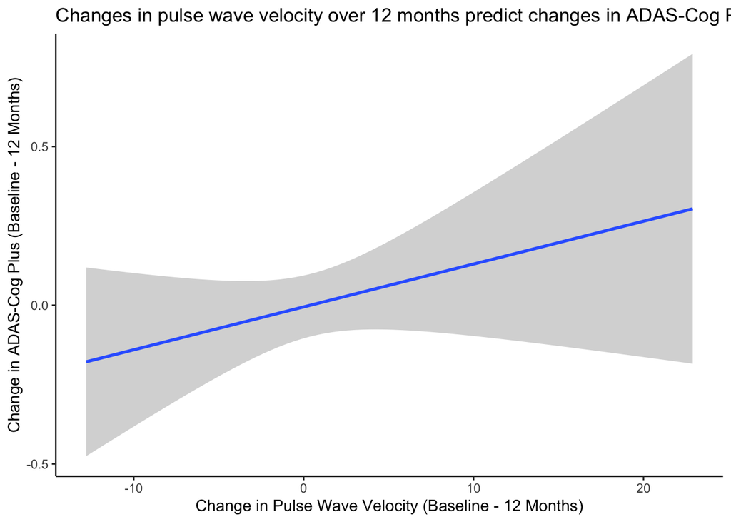

```r
resid.ADAS.lm<-lm(Change.ADAS~Age + Sex +Group, data = wide.data4)
resid.PWV.lm<-lm(Change.PWV~Age + Sex + Group, data = wide.data4)
resid.ADAS<-residuals(resid.ADAS.lm)
resid.PWV<-residuals(resid.PWV.lm)

PWV.ADAS.Graph<-as.data.frame(cbind(resid.ADAS,resid.PWV))
ggplot(PWV.ADAS.Graph, aes(x = resid.PWV, y = resid.ADAS)) +
  geom_smooth(method = 'lm') +
  theme_bw() +
  theme(panel.border = element_blank(),
        panel.grid.major = element_blank(),
        panel.grid.minor = element_blank(),
        axis.line = element_line(colour = "black")) +
  labs(title = "Changes in pulse wave velocity over 12 months predict changes in ADAS-Cog Plus performance",
       x = "Change in Pulse Wave Velocity (Baseline - 12 Months)",
       y = "Change in ADAS-Cog Plus (Baseline - 12 Months)")
```